# Project with Arvato: Identify Customer Segments

#### Step 1.2.1: Re-Encode Categorical Features

For categorical data, we need to encode the levels as dummy variables.

```python
# Assess categorical variables: which are binary, which are multi-level, and which one needs to be re-encoded?
cat_cols=list(feat_info.loc[feat_info['type']=='categorical']['attribute'])
bi_cols=[]
bi_non_num=[]
multi_cols=[]

for col in cat_cols:
    if azdias[col].nunique()>2: #if multi_cols
        multi_cols.append(col)
    elif azdias[col].dtype=='object':
        bi_non_num.append(col)
    else:
        bi_cols.append(col)
```

```python
print('Assesment categorical variables:')
print('Binary\n', bi_cols, '\nBinary non-numeric\n', bi_non_num, '\nMultilevel \n', multi_cols)
```

```
Assesment categorical variables:
Binary
 ['ANREDE_KZ', 'GREEN_AVANTGARDE', 'SOHO_KZ', 'VERS_TYP']
Binary non-numeric
 ['OST_WEST_KZ']
Multilevel
 ['CJT_GESAMTTYP', 'FINANZTYP', 'GFK_URLAUBERTYP', 'LP_FAMILIE_FEIN', 'LP_FAMILIE_GROB', 'LP_STATUS_FEIN', 'LP_STATUS_GROB', 'NATIONALITAET_KZ', 'SHOPPER_TYP', 'ZABEOTYP', 'GEBAEUDETYP', 'CAMEO_DEUG_2015', 'CAMEO_DEU_2015']
```

```python
for bi in bi_non_num:
    print('Binary non-numeric:',bi)
    print('Unique values:',azdias[bi].unique())
    print('Counts:\n', azdias[bi].value_counts(dropna=False))
```

```
Binary non-numeric: OST_WEST_KZ
Unique values: [nan 'W' 'O']
Counts:
 W      629528
O      168545
NaN     93148
Name: OST_WEST_KZ, dtype: int64
```

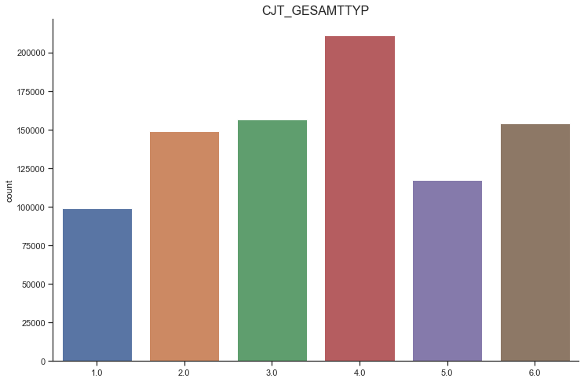

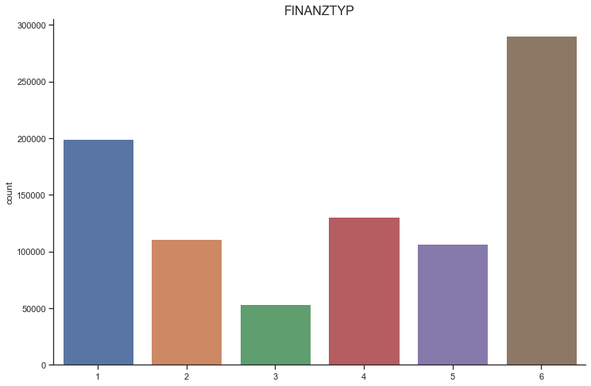

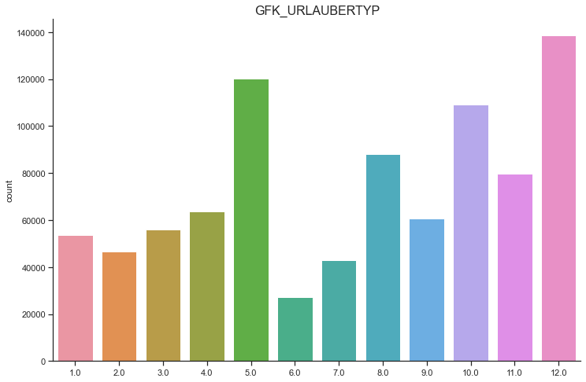

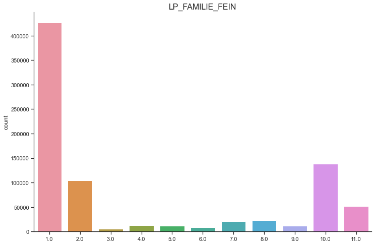

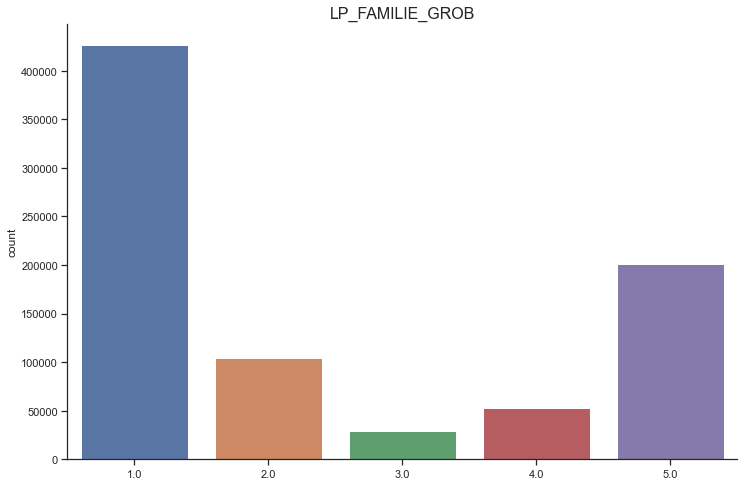

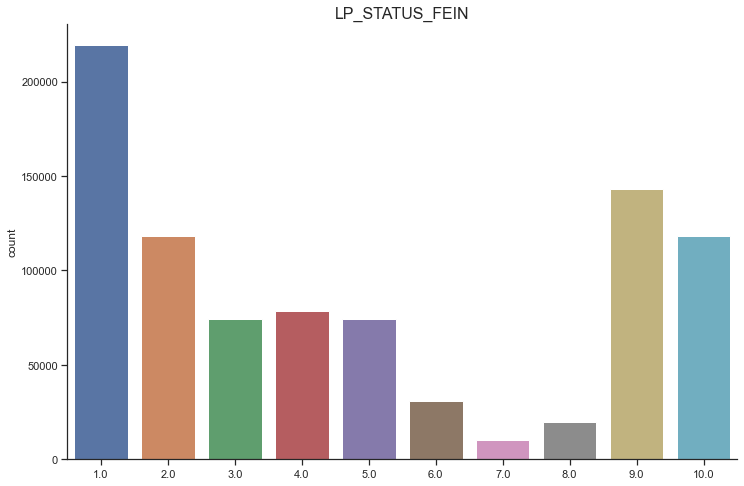

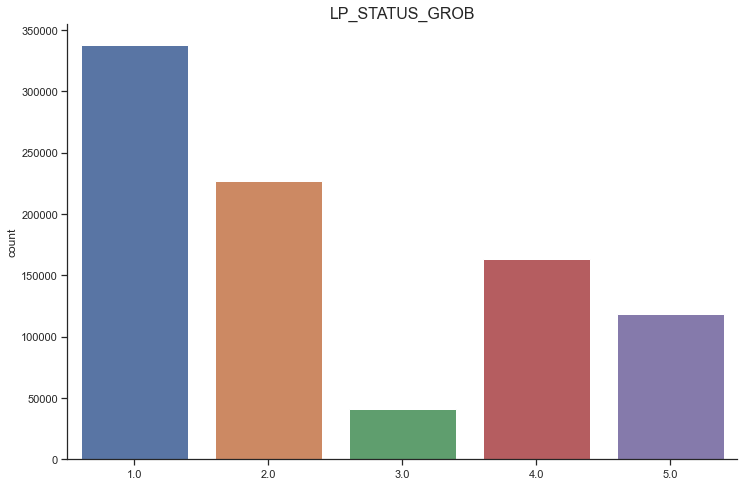

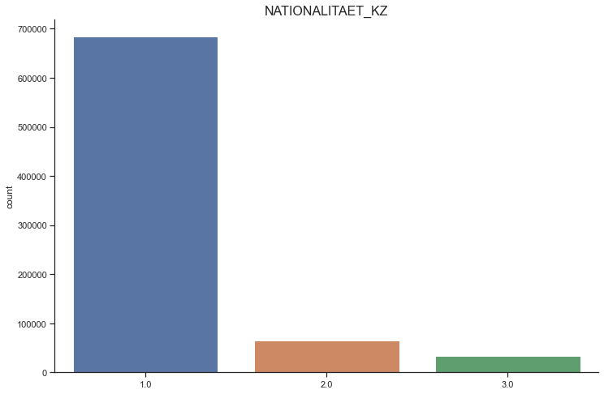

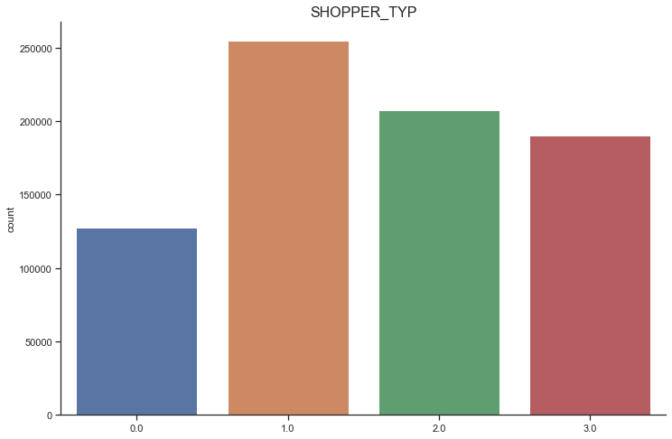

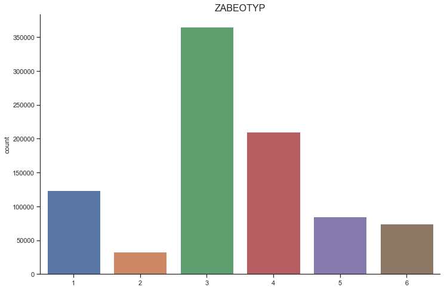

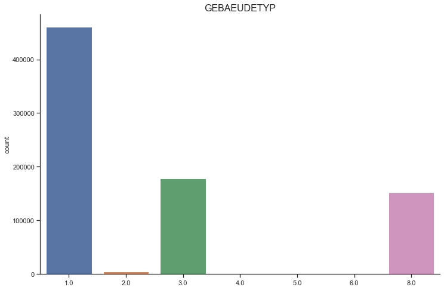

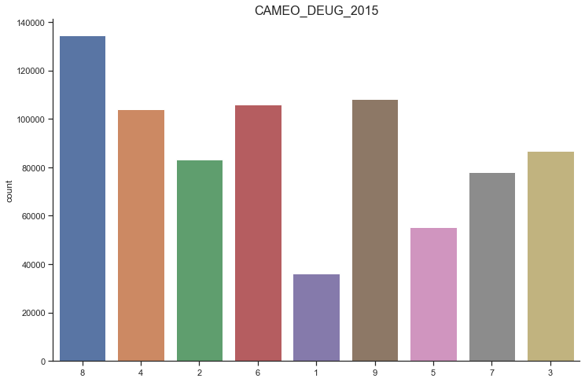

[1 more figures not shown]

```python
for col in multi_cols:
    sns.countplot(azdias[col].values)
    plt.title(col, fontsize=16)
    plt.show()
```

> After reviewing the Data_Dictionary definitions for each variable, decided to keep the following multi-level features and remove the rest.
> - CJT_GESAMTTYP:Customer-Journey-Typology: preferred information and buying channels for consumer
> - FINANZTYP: Most descriptive financial type for individual

> Encoding via pandas get_dummies instead as OneHotEncoding, as it creates k-1 dummy variables instead of k (number of variables) https://towardsdatascience.com/encoding-categorical-variables-one-hot-vs-dummy-encoding-6d5b9c46e2db

```python
# Re-encode categorical variable(s) to be kept in the analysis.
# re-encode the values as numbers
azdias.loc[:, 'OST_WEST_KZ'].replace({'W':0, 'O':1}, inplace=True)
print(azdias.describe(include='all'))

#selected multi-level features that we will keep. Removed the rest multi level from list
multi_sel=['CJT_GESAMTTYP','FINANZTYP']
for sel in multi_sel:
    multi_cols.remove(sel)#, inplace=True)

# dropping the multilevel categorical columns
azdias.drop(multi_cols, axis=1, inplace=True)
#checking size
print(azdias.shape)
print(azdias.describe(include='all'))
```

```
        ALTERSKATEGORIE_GROB      ANREDE_KZ  CJT_GESAMTTYP  FINANZ_MINIMALIST  \
count          888340.000000  891221.000000  886367.000000      891221.000000
unique                   NaN            NaN            NaN                NaN
top                      NaN            NaN            NaN                NaN
freq                     NaN            NaN            NaN                NaN
mean                2.757217       1.522098       3.632838           3.074528
std                 1.009951       0.499512       1.595021           1.321055
min                 1.000000       1.000000       1.000000           1.000000
25%                 2.000000       1.000000       2.000000           2.000000
50%                 3.000000       2.000000       4.000000           3.000000
75%                 4.000000       2.000000       5.000000           4.000000
max                 4.000000       2.000000       6.000000           5.000000

        FINANZ_SPARER  FINANZ_VORSORGER  FINANZ_ANLEGER  \
count   891221.000000     891221.000000   891221.000000
unique            NaN               NaN             NaN
top               NaN               NaN             NaN
freq              NaN               NaN             NaN
mean         2.821039          3.401106        3.033328
std          1.464749          1.322134        1.529603
min          1.000000          1.000000        1.000000
25%          1.000000          3.000000        2.000000
50%          3.000000          3.000000        3.000000
75%          4.000000          5.000000        5.000000
max          5.000000          5.000000        5.000000

        FINANZ_UNAUFFAELLIGER  FINANZ_HAUSBAUER      FINANZTYP  \
count           891221.000000     891221.000000  891221.000000
unique                    NaN               NaN            NaN
top                       NaN               NaN            NaN
freq                      NaN               NaN            NaN
mean                 2.874167          3.075121       3.790586
std                  1.486731          1.353248       1.987876
min                  1.000000          1.000000       1.000000
25%                  2.000000          2.000000       2.000000
50%                  3.000000          3.000000       4.000000
75%                  4.000000          4.000000       6.000000
max                  5.000000          5.000000       6.000000

        GFK_URLAUBERTYP  GREEN_AVANTGARDE     HEALTH_TYP  LP_LEBENSPHASE_FEIN  \
```

[output cut: 451 more lines]

```
75%          2.000000       1.000000       3.000000       4.000000
max          3.000000       2.000000       5.000000       5.000000

             PLZ8_GBZ         ARBEIT    ORTSGR_KLS9       RELAT_AB
count   774706.000000  793846.000000  793947.000000  793846.000000
unique            NaN            NaN            NaN            NaN
top               NaN            NaN            NaN            NaN
freq              NaN            NaN            NaN            NaN
mean         3.381087       3.166686       5.293389       3.071033
std          1.111598       0.999072       2.303379       1.360532
min          1.000000       1.000000       1.000000       1.000000
25%          3.000000       3.000000       4.000000       2.000000
50%          3.000000       3.000000       5.000000       3.000000
75%          4.000000       4.000000       7.000000       4.000000
max          5.000000       5.000000       9.000000       5.000000
```

```python
#Encoding categorical variables: selected multi-level variables
azdias_encoded=pd.get_dummies(azdias, columns=multi_sel, drop_first=True )
print(azdias_encoded.shape)
azdias_encoded.describe()
```

```
(891221, 76)
```

|  | ALTERSKATEGORIE_GROB | ANREDE_KZ | FINANZ_MINIMALIST | FINANZ_SPARER | FINANZ_VORSORGER | FINANZ_ANLEGER | FINANZ_UNAUFFAELLIGER | FINANZ_HAUSBAUER | GREEN_AVANTGARDE | HEALTH_TYP | LP_LEBENSPHASE_FEIN | LP_LEBENSPHASE_GROB | PRAEGENDE_JUGENDJAHRE | RETOURTYP_BK_S | SEMIO_SOZ | SEMIO_FAM | SEMIO_REL | SEMIO_MAT | SEMIO_VERT | SEMIO_LUST | SEMIO_ERL | SEMIO_KULT | SEMIO_RAT | SEMIO_KRIT | SEMIO_DOM | SEMIO_KAEM | SEMIO_PFLICHT | SEMIO_TRADV | SOHO_KZ | … |
| --- | --- | --- | --- | --- | --- | --- | --- | --- | --- | --- | --- | --- | --- | --- | --- | --- | --- | --- | --- | --- | --- | --- | --- | --- | --- | --- | --- | --- | --- | --- |
| count | 888340.000000 | 891221.000000 | 891221.000000 | 891221.000000 | 891221.000000 | 891221.000000 | 891221.000000 | 891221.000000 | 891221.000000 | 780025.000000 | 793589.000000 | 796649.000000 | 783057.000000 | 886367.000000 | 891221.000000 | 891221.000000 | 891221.000000 | 891221.000000 | 891221.000000 | 891221.000000 | 891221.000000 | 891221.000000 | 891221.000000 | 891221.000000 | 891221.000000 | 891221.000000 | 891221.000000 | 891221.000000 | 817722.000000 | … |
| mean | 2.757217 | 1.522098 | 3.074528 | 2.821039 | 3.401106 | 3.033328 | 2.874167 | 3.075121 | 0.196612 | 2.190129 | 16.332161 | 4.955185 | 9.280709 | 3.419630 | 3.945860 | 4.272729 | 4.240609 | 4.001597 | 4.023709 | 4.359086 | 4.481405 | 4.025014 | 3.910139 | 4.763223 | 4.667550 | 4.445007 | 4.256076 | 3.661784 | 0.008423 | … |
| std | 1.009951 | 0.499512 | 1.321055 | 1.464749 | 1.322134 | 1.529603 | 1.486731 | 1.353248 | 0.397437 | 0.755213 | 12.242378 | 3.748974 | 4.032107 | 1.417741 | 1.946564 | 1.915885 | 2.007373 | 1.857540 | 2.077746 | 2.022829 | 1.807552 | 1.903816 | 1.580306 | 1.830789 | 1.795712 | 1.852412 | 1.770137 | 1.707637 | 0.091392 | … |
| min | 1.000000 | 1.000000 | 1.000000 | 1.000000 | 1.000000 | 1.000000 | 1.000000 | 1.000000 | 0.000000 | 1.000000 | 1.000000 | 1.000000 | 1.000000 | 1.000000 | 1.000000 | 1.000000 | 1.000000 | 1.000000 | 1.000000 | 1.000000 | 1.000000 | 1.000000 | 1.000000 | 1.000000 | 1.000000 | 1.000000 | 1.000000 | 1.000000 | 0.000000 | … |
| 25% | 2.000000 | 1.000000 | 2.000000 | 1.000000 | 3.000000 | 2.000000 | 2.000000 | 2.000000 | 0.000000 | 2.000000 | 6.000000 | 2.000000 | 6.000000 | 2.000000 | 2.000000 | 3.000000 | 3.000000 | 2.000000 | 2.000000 | 2.000000 | 3.000000 | 3.000000 | 3.000000 | 3.000000 | 3.000000 | 3.000000 | 3.000000 | 2.000000 | 0.000000 | … |
| 50% | 3.000000 | 2.000000 | 3.000000 | 3.000000 | 3.000000 | 3.000000 | 3.000000 | 3.000000 | 0.000000 | 2.000000 | 13.000000 | 3.000000 | 9.000000 | 3.000000 | 4.000000 | 4.000000 | 4.000000 | 4.000000 | 4.000000 | 5.000000 | 4.000000 | 4.000000 | 4.000000 | 5.000000 | 5.000000 | 5.000000 | 4.000000 | 3.000000 | 0.000000 | … |
| 75% | 4.000000 | 2.000000 | 4.000000 | 4.000000 | 5.000000 | 5.000000 | 4.000000 | 4.000000 | 0.000000 | 3.000000 | 28.000000 | 8.000000 | 14.000000 | 5.000000 | 6.000000 | 6.000000 | 6.000000 | 5.000000 | 6.000000 | 6.000000 | 6.000000 | 5.000000 | 5.000000 | 6.000000 | 6.000000 | 6.000000 | 6.000000 | 5.000000 | 0.000000 | … |
| max | 4.000000 | 2.000000 | 5.000000 | 5.000000 | 5.000000 | 5.000000 | 5.000000 | 5.000000 | 1.000000 | 3.000000 | 40.000000 | 12.000000 | 15.000000 | 5.000000 | 7.000000 | 7.000000 | 7.000000 | 7.000000 | 7.000000 | 7.000000 | 7.000000 | 7.000000 | 7.000000 | 7.000000 | 7.000000 | 7.000000 | 7.000000 | 7.000000 | 1.000000 | … |

#### Step 1.2.2: Engineer Mixed-Type Features

There are a handful of features that are marked as "mixed" in the feature summary that require special treatment in order to be included in the analysis. There are two in particular that deserve attention:

- "PRAEGENDE_JUGENDJAHRE" combines information on three dimensions: generation by decade, movement (mainstream vs. avantgarde), and nation (east vs. west). While there aren't enough levels to disentangle east from west, you should create two new variables to capture the other two dimensions: an interval-type variable for decade, and a binary variable for movement.
- "CAMEO_INTL_2015" combines information on two axes: wealth and life stage. Break up the two-digit codes by their 'tens'-place and 'ones'-place digits into two new ordinal variables (which, for the purposes of this project, is equivalent to just treating them as their raw numeric values).

```python
#mixed columns names
mixed_cols=list(feat_info.loc[feat_info['type']=='mixed']['attribute'])
azdias_encoded[mixed_cols].nunique()
```

```
LP_LEBENSPHASE_FEIN      40
LP_LEBENSPHASE_GROB      12
PRAEGENDE_JUGENDJAHRE    15
WOHNLAGE                  8
CAMEO_INTL_2015          21
PLZ8_BAUMAX               5
dtype: int64
```

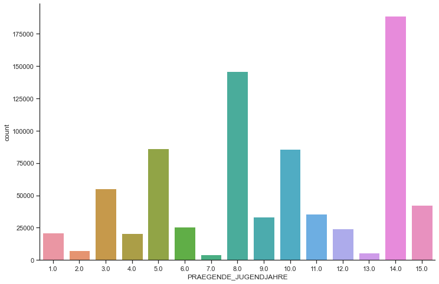

```python
# Investigate "PRAEGENDE_JUGENDJAHRE" and engineer two new variables.
sns.countplot(azdias_encoded['PRAEGENDE_JUGENDJAHRE'])
plt.show()
```

##### PRAEGENDE_JUGENDJAHRE

Dominating movement of person's youth (avantgarde vs. mainstream; east vs. west)

- 1: 40s - war years (Mainstream, E+W)
- 2: 40s - reconstruction years (Avantgarde, E+W)
- 3: 50s - economic miracle (Mainstream, E+W)
- 4: 50s - milk bar / Individualisation (Avantgarde, E+W)
- 5: 60s - economic miracle (Mainstream, E+W)
- 6: 60s - generation 68 / student protestors (Avantgarde, W)
- 7: 60s - opponents to the building of the Wall (Avantgarde, E)
- 8: 70s - family orientation (Mainstream, E+W)
- 9: 70s - peace movement (Avantgarde, E+W)
- 10: 80s - Generation Golf (Mainstream, W)
- 11: 80s - ecological awareness (Avantgarde, W)
- 12: 80s - FDJ / communist party youth organisation (Mainstream, E)
- 13: 80s - Swords into ploughshares (Avantgarde, E)
- 14: 90s - digital media kids (Mainstream, E+W)
- 15: 90s - ecological awareness (Avantgarde, E+W)

```python
#encoding decade
decade_encoding={1:40, 2:40, 3:50, 4:50, 5:60,6:60,7:60,8:70,9:70,10:80,11:80,12:80,13:80,14:90,15:90}
azdias_encoded['decade']=azdias_encoded.loc[:, 'PRAEGENDE_JUGENDJAHRE'].replace(decade_encoding)
azdias_encoded['decade'].value_counts()
```

```
90.0    231244
70.0    179558
80.0    151770
60.0    116078
50.0     75646
40.0     28761
Name: decade, dtype: int64
```

```python
#encoding movement (Mainstream=1, Avantgarde=0)
mov_encoding={1:1, 2:0, 3:1, 4:0, 5:1, 6:0, 7:0, 8:1, 9:0, 10:1, 11:0, 12:1, 13:0, 14:1,15:0}
azdias_encoded['movement']=azdias_encoded.loc[:, 'PRAEGENDE_JUGENDJAHRE'].replace(mov_encoding)
azdias_encoded['movement'].value_counts()
```

```
1.0    607832
0.0    175225
Name: movement, dtype: int64
```

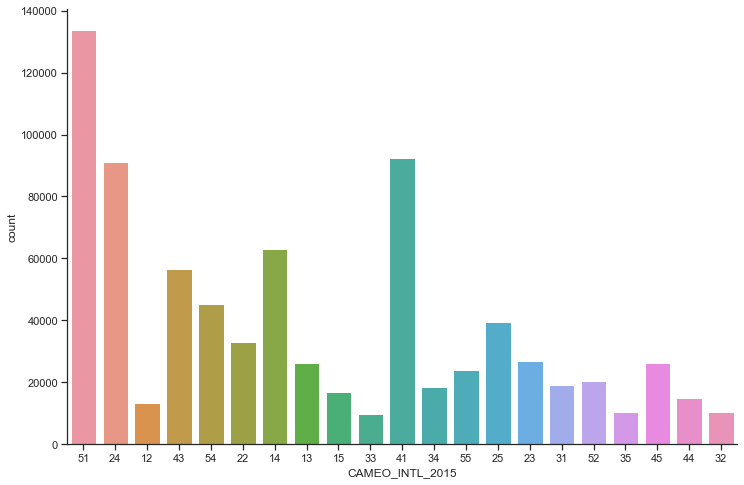

```python
# Investigate "CAMEO_INTL_2015" and engineer two new variables.
sns.countplot(azdias_encoded['CAMEO_INTL_2015'])
plt.show()
```

##### CAMEO_INTL_2015

German CAMEO: Wealth / Life Stage Typology, mapped to international code

- 11: Wealthy Households - Pre-Family Couples & Singles
- 12: Wealthy Households - Young Couples With Children
- 13: Wealthy Households - Families With School Age Children
- 14: Wealthy Households - Older Families & Mature Couples
- 15: Wealthy Households - Elders In Retirement
- 21: Prosperous Households - Pre-Family Couples & Singles
- 22: Prosperous Households - Young Couples With Children
- 23: Prosperous Households - Families With School Age Children
- 24: Prosperous Households - Older Families & Mature Couples
- 25: Prosperous Households - Elders In Retirement
- 31: Comfortable Households - Pre-Family Couples & Singles
- 32: Comfortable Households - Young Couples With Children
- 33: Comfortable Households - Families With School Age Children
- 34: Comfortable Households - Older Families & Mature Couples
- 35: Comfortable Households - Elders In Retirement
- 41: Less Affluent Households - Pre-Family Couples & Singles
- 42: Less Affluent Households - Young Couples With Children
- 43: Less Affluent Households - Families With School Age Children
- 44: Less Affluent Households - Older Families & Mature Couples
- 45: Less Affluent Households - Elders In Retirement
- 51: Poorer Households - Pre-Family Couples & Singles
- 52: Poorer Households - Young Couples With Children
- 53: Poorer Households - Families With School Age Children
- 54: Poorer Households - Older Families & Mature Couples
- 55: Poorer Households - Elders In Retirement

```python
#encoding wealth
azdias_encoded['Wealth']=[int(str(row)[0]) if pd.isna(row)==False else row for row in azdias_encoded['CAMEO_INTL_2015'] ]
azdias_encoded['Wealth'].value_counts()
```

```
5.0    223582
2.0    190691
4.0    189960
1.0    119443
3.0     68193
Name: Wealth, dtype: int64
```

```python
#encoding life stage
azdias_encoded['Life_stage']=[int(str(row)[1]) if pd.isna(row)==False else row for row in azdias_encoded['CAMEO_INTL_2015'] ]
azdias_encoded['Life_stage'].value_counts()
```

```
1.0    245054
4.0    232777
3.0    119693
5.0    117045
2.0     77300
Name: Life_stage, dtype: int64
```

```python
print(azdias_encoded.shape)
azdias_encoded.drop(mixed_cols, axis=1, inplace=True)
print(azdias_encoded.shape)
```

```
(891221, 80)
(891221, 74)
```

#### Discussion 1.2.2: Engineer Mixed-Type Features

> - 6 columns originally typed as 'mixed': LP_LEBENSPHASE_FEIN(40), LP_LEBENSPHASE_GROB(12), PRAEGENDE_JUGENDJAHRE(15), WOHNLAGE(8), CAMEO_INTL_2015(21), PLZ8_BAUMAX(5)
> - Engineered PRAEGENDE_JUGENDJAHRE and CAMEO_INTL_2015, and removed the rest.
> - Engineered two different features from PRAEGENDE_JUGENDJAHRE: decade (multi-level categorical) and movement (binary).
> - Engineered two different features from CAMEO_INTL_2015: Wealth and Life_Stage as defined in Data_Dictionary.md
> - Removed PRAEGENDE_JUGENDJAHRE and CAMEO_INTL_2015 after extracting the above mentioned features.

#### Step 1.2.3: Complete Feature Selection

To summarize, the dataframe should consist of the following:

- All numeric, interval, and ordinal type columns from the original dataset.
- Binary categorical features (all numerically-encoded).
- Engineered features from other multi-level categorical features and mixed features.

Make sure that:

- For any new columns that you have engineered, that you've excluded the original columns from the final dataset.
- Data should only be from **the subset with few or no missing values**.

```python
# If there are other re-engineering tasks you need to perform, make sure you
# take care of them here. (Dealing with missing data will come in step 2.1.)
azdias_encoded.describe(include='all').T
```

|  | count | mean | std | min | 25% | 50% | 75% | max |
| --- | --- | --- | --- | --- | --- | --- | --- | --- |
| ALTERSKATEGORIE_GROB | 888340.0 | 2.757217 | 1.009951 | 1.0 | 2.0 | 3.0 | 4.0 | 4.0 |
| ANREDE_KZ | 891221.0 | 1.522098 | 0.499512 | 1.0 | 1.0 | 2.0 | 2.0 | 2.0 |
| FINANZ_MINIMALIST | 891221.0 | 3.074528 | 1.321055 | 1.0 | 2.0 | 3.0 | 4.0 | 5.0 |
| FINANZ_SPARER | 891221.0 | 2.821039 | 1.464749 | 1.0 | 1.0 | 3.0 | 4.0 | 5.0 |
| FINANZ_VORSORGER | 891221.0 | 3.401106 | 1.322134 | 1.0 | 3.0 | 3.0 | 5.0 | 5.0 |
| FINANZ_ANLEGER | 891221.0 | 3.033328 | 1.529603 | 1.0 | 2.0 | 3.0 | 5.0 | 5.0 |
| FINANZ_UNAUFFAELLIGER | 891221.0 | 2.874167 | 1.486731 | 1.0 | 2.0 | 3.0 | 4.0 | 5.0 |
| FINANZ_HAUSBAUER | 891221.0 | 3.075121 | 1.353248 | 1.0 | 2.0 | 3.0 | 4.0 | 5.0 |
| GREEN_AVANTGARDE | 891221.0 | 0.196612 | 0.397437 | 0.0 | 0.0 | 0.0 | 0.0 | 1.0 |
| HEALTH_TYP | 780025.0 | 2.190129 | 0.755213 | 1.0 | 2.0 | 2.0 | 3.0 | 3.0 |
| RETOURTYP_BK_S | 886367.0 | 3.419630 | 1.417741 | 1.0 | 2.0 | 3.0 | 5.0 | 5.0 |
| SEMIO_SOZ | 891221.0 | 3.945860 | 1.946564 | 1.0 | 2.0 | 4.0 | 6.0 | 7.0 |
| SEMIO_FAM | 891221.0 | 4.272729 | 1.915885 | 1.0 | 3.0 | 4.0 | 6.0 | 7.0 |
| SEMIO_REL | 891221.0 | 4.240609 | 2.007373 | 1.0 | 3.0 | 4.0 | 6.0 | 7.0 |
| SEMIO_MAT | 891221.0 | 4.001597 | 1.857540 | 1.0 | 2.0 | 4.0 | 5.0 | 7.0 |
| SEMIO_VERT | 891221.0 | 4.023709 | 2.077746 | 1.0 | 2.0 | 4.0 | 6.0 | 7.0 |
| SEMIO_LUST | 891221.0 | 4.359086 | 2.022829 | 1.0 | 2.0 | 5.0 | 6.0 | 7.0 |
| SEMIO_ERL | 891221.0 | 4.481405 | 1.807552 | 1.0 | 3.0 | 4.0 | 6.0 | 7.0 |
| SEMIO_KULT | 891221.0 | 4.025014 | 1.903816 | 1.0 | 3.0 | 4.0 | 5.0 | 7.0 |
| SEMIO_RAT | 891221.0 | 3.910139 | 1.580306 | 1.0 | 3.0 | 4.0 | 5.0 | 7.0 |
| SEMIO_KRIT | 891221.0 | 4.763223 | 1.830789 | 1.0 | 3.0 | 5.0 | 6.0 | 7.0 |
| SEMIO_DOM | 891221.0 | 4.667550 | 1.795712 | 1.0 | 3.0 | 5.0 | 6.0 | 7.0 |
| SEMIO_KAEM | 891221.0 | 4.445007 | 1.852412 | 1.0 | 3.0 | 5.0 | 6.0 | 7.0 |
| SEMIO_PFLICHT | 891221.0 | 4.256076 | 1.770137 | 1.0 | 3.0 | 4.0 | 6.0 | 7.0 |
| SEMIO_TRADV | 891221.0 | 3.661784 | 1.707637 | 1.0 | 2.0 | 3.0 | 5.0 | 7.0 |
| SOHO_KZ | 817722.0 | 0.008423 | 0.091392 | 0.0 | 0.0 | 0.0 | 0.0 | 1.0 |
| VERS_TYP | 780025.0 | 1.511166 | 0.499876 | 1.0 | 1.0 | 2.0 | 2.0 | 2.0 |
| ANZ_PERSONEN | 817722.0 | 1.727637 | 1.155849 | 0.0 | 1.0 | 1.0 | 2.0 | 45.0 |
| ANZ_TITEL | 817722.0 | 0.004162 | 0.068855 | 0.0 | 0.0 | 0.0 | 0.0 | 6.0 |
| HH_EINKOMMEN_SCORE | 872873.0 | 4.207243 | 1.624057 | 1.0 | 3.0 | 5.0 | 6.0 | 6.0 |
| W_KEIT_KIND_HH | 743233.0 | 4.147141 | 1.784211 | 1.0 | 3.0 | 4.0 | 6.0 | 6.0 |
| WOHNDAUER_2008 | 817722.0 | 7.908791 | 1.923137 | 1.0 | 8.0 | 9.0 | 9.0 | 9.0 |
| ANZ_HAUSHALTE_AKTIV | 791610.0 | 8.354924 | 15.673731 | 1.0 | 2.0 | 4.0 | 10.0 | 595.0 |
| ANZ_HH_TITEL | 794213.0 | 0.040647 | 0.324028 | 0.0 | 0.0 | 0.0 | 0.0 | 23.0 |
| KONSUMNAEHE | 817252.0 | 3.018452 | 1.550312 | 1.0 | 2.0 | 3.0 | 4.0 | 7.0 |
| MIN_GEBAEUDEJAHR | 798073.0 | 1993.277011 | 3.332739 | 1985.0 | 1992.0 | 1992.0 | 1993.0 | 2016.0 |
| OST_WEST_KZ | 798073.0 | 0.211190 | 0.408153 | 0.0 | 0.0 | 0.0 | 0.0 | 1.0 |
| KBA05_ANTG1 | 757897.0 | 1.494277 | 1.403961 | 0.0 | 0.0 | 1.0 | 3.0 | 4.0 |
| KBA05_ANTG2 | 757897.0 | 1.265584 | 1.245178 | 0.0 | 0.0 | 1.0 | 2.0 | 4.0 |
| KBA05_ANTG3 | 757897.0 | 0.624525 | 1.013443 | 0.0 | 0.0 | 0.0 | 1.0 | 3.0 |
| KBA05_ANTG4 | 757897.0 | 0.305927 | 0.638725 | 0.0 | 0.0 | 0.0 | 0.0 | 2.0 |
| KBA05_GBZ | 757897.0 | 3.158580 | 1.329537 | 1.0 | 2.0 | 3.0 | 4.0 | 5.0 |
| BALLRAUM | 797481.0 | 4.153043 | 2.183710 | 1.0 | 2.0 | 5.0 | 6.0 | 7.0 |
| EWDICHTE | 797481.0 | 3.939172 | 1.718996 | 1.0 | 2.0 | 4.0 | 6.0 | 6.0 |
| INNENSTADT | 797481.0 | 4.549491 | 2.028919 | 1.0 | 3.0 | 5.0 | 6.0 | 8.0 |
| GEBAEUDETYP_RASTER | 798066.0 | 3.738306 | 0.923193 | 1.0 | 3.0 | 4.0 | 4.0 | 5.0 |
| KKK | 733157.0 | 2.723384 | 0.979867 | 1.0 | 2.0 | 3.0 | 3.0 | 4.0 |
| MOBI_REGIO | 757897.0 | 2.963540 | 1.428882 | 1.0 | 2.0 | 3.0 | 4.0 | 6.0 |
| ONLINE_AFFINITAET | 886367.0 | 2.698691 | 1.521524 | 0.0 | 1.0 | 3.0 | 4.0 | 5.0 |
| REGIOTYP | 733157.0 | 4.472086 | 1.836357 | 1.0 | 3.0 | 5.0 | 6.0 | 7.0 |
| KBA13_ANZAHL_PKW | 785421.0 | 619.701439 | 340.034318 | 0.0 | 384.0 | 549.0 | 778.0 | 2300.0 |
| PLZ8_ANTG1 | 774706.0 | 2.253330 | 0.972008 | 0.0 | 1.0 | 2.0 | 3.0 | 4.0 |
| PLZ8_ANTG2 | 774706.0 | 2.801858 | 0.920309 | 0.0 | 2.0 | 3.0 | 3.0 | 4.0 |
| PLZ8_ANTG3 | 774706.0 | 1.595426 | 0.986736 | 0.0 | 1.0 | 2.0 | 2.0 | 3.0 |
| PLZ8_ANTG4 | 774706.0 | 0.699166 | 0.727137 | 0.0 | 0.0 | 1.0 | 1.0 | 2.0 |
| PLZ8_HHZ | 774706.0 | 3.612821 | 0.973967 | 1.0 | 3.0 | 4.0 | 4.0 | 5.0 |
| PLZ8_GBZ | 774706.0 | 3.381087 | 1.111598 | 1.0 | 3.0 | 3.0 | 4.0 | 5.0 |
| ARBEIT | 793846.0 | 3.166686 | 0.999072 | 1.0 | 3.0 | 3.0 | 4.0 | 5.0 |
| ORTSGR_KLS9 | 793947.0 | 5.293389 | 2.303379 | 1.0 | 4.0 | 5.0 | 7.0 | 9.0 |
| RELAT_AB | 793846.0 | 3.071033 | 1.360532 | 1.0 | 2.0 | 3.0 | 4.0 | 5.0 |
| CJT_GESAMTTYP_2.0 | 891221.0 | 0.166956 | 0.372937 | 0.0 | 0.0 | 0.0 | 0.0 | 1.0 |
| CJT_GESAMTTYP_3.0 | 891221.0 | 0.175545 | 0.380432 | 0.0 | 0.0 | 0.0 | 0.0 | 1.0 |
| CJT_GESAMTTYP_4.0 | 891221.0 | 0.236712 | 0.425064 | 0.0 | 0.0 | 0.0 | 0.0 | 1.0 |
| CJT_GESAMTTYP_5.0 | 891221.0 | 0.131702 | 0.338167 | 0.0 | 0.0 | 0.0 | 0.0 | 1.0 |
| CJT_GESAMTTYP_6.0 | 891221.0 | 0.172701 | 0.377989 | 0.0 | 0.0 | 0.0 | 0.0 | 1.0 |
| FINANZTYP_2 | 891221.0 | 0.124399 | 0.330036 | 0.0 | 0.0 | 0.0 | 0.0 | 1.0 |
| FINANZTYP_3 | 891221.0 | 0.059866 | 0.237239 | 0.0 | 0.0 | 0.0 | 0.0 | 1.0 |
| FINANZTYP_4 | 891221.0 | 0.146569 | 0.353676 | 0.0 | 0.0 | 0.0 | 0.0 | 1.0 |
| FINANZTYP_5 | 891221.0 | 0.119427 | 0.324291 | 0.0 | 0.0 | 0.0 | 0.0 | 1.0 |
| FINANZTYP_6 | 891221.0 | 0.325808 | 0.468676 | 0.0 | 0.0 | 0.0 | 1.0 | 1.0 |
| decade | 783057.0 | 73.328046 | 14.592844 | 40.0 | 60.0 | 70.0 | 90.0 | 90.0 |
| movement | 783057.0 | 0.776230 | 0.416770 | 0.0 | 1.0 | 1.0 | 1.0 | 1.0 |
| Wealth | 791869.0 | 3.262098 | 1.464494 | 1.0 | 2.0 | 4.0 | 5.0 | 5.0 |
| Life_stage | 791869.0 | 2.873033 | 1.484771 | 1.0 | 1.0 | 3.0 | 4.0 | 5.0 |

### Step 1.3: Create a Cleaning Function

Even though the general population demographics data has been cleaned up, it's important to look ahead to the future and realize that the same cleaning steps will need to be performed on the customer demographics data. The function below to execute the main feature selection, encoding, and re-engineering steps performed above.

Go back to Index

```python
#Auxiliary cleaning functions

def drop_cols(df,mapper):
    ''' Identifies and drops features with >34% of missing values
        Input: dataframe with missing values encoded as NaN
        Output: df without columns with >34% missing values
    '''
    data_nan=pd.DataFrame({'total_missing':df.isnull().sum().sort_values(ascending=False),
                           '%_missing':np.round((df.isnull().mean()*100).sort_values(ascending=False),2)})
    features_drop=data_nan.loc[data_nan['%_missing']>34].index.tolist()
    df=df.drop(features_drop, axis=1)
    #removing columns from mapper df
    mapper=mapper.loc[~mapper.attribute.isin(features_drop)]
    return df, mapper

def drop_rows(df):
    ''' Identifies and drops rows with >15% of missing values
        Input: dataframe with missing values encoded as NaN
        Output: df without rows with >15% missing values
    '''
    data_nan_row=pd.DataFrame({'total_missing':df.isnull().sum(axis=1),
                               '%_missing':np.round((df.isnull().mean(axis=1)*100),2)})
    lowna_df=df.loc[data_nan_row['%_missing']<15]
    return lowna_df

def encode_cat(df, mapper):
    ''' Identifies categorical features and re-encodes the values as numbers
        Input: dataframe with missing values encoded as NaN
        Output: df with numerical categorical features
    '''
    # Assess categorical variables: which are binary, which are multi-level, and which one needs to be re-encoded?
    cat_cols=list(mapper.loc[mapper['type']=='categorical']['attribute'])
    bi_cols=[]
    bi_non_num=[]
    multi_cols=[]
    for col in cat_cols:
        if df[col].nunique()>2: #if multi_cols
            multi_cols.append(col)
        elif df[col].dtype=='object':
            bi_non_num.append(col)
        else:
            bi_cols.append(col)

    # re-encode non_num Binary variables as numbers
    for bi in bi_non_num:
        df.loc[:, bi].replace({'W':0, 'O':1}, inplace=True)

    #Multi-level features that we will keep. Removed the rest multi level from list
    multi_sel=['CJT_GESAMTTYP','FINANZTYP']
    for sel in multi_sel:
        if sel in multi_cols:
            multi_cols.remove(sel)#, inplace=True)
    #Dropping the multilevel categorical columns not in multi_sel list
    df.drop(multi_cols, axis=1, inplace=True)
    #Encoding categorical variables: selected multi-level variables
    df=pd.get_dummies(df, columns=multi_sel, drop_first=True )#dummy_na=True

    return df

def engineer_mix(df,mapper):
    ''' Identifies 'mixed' features, drops most of them and engineers 'PRAEGENDE_JUGENDJAHRE' and 'CAMEO_INTL_2015'
        Input: dataframe with missing values encoded as NaN
        Output: df with 'PRAEGENDE_JUGENDJAHRE' and 'CAMEO_INTL_2015' features deconstructed
    '''
    #encoding decade (40's=0,50's=1,60's=2,70's=3,80's=4,90's=5)
    if 'PRAEGENDE_JUGENDJAHRE' in df.columns:
        decade_encoding={1:0, 2:0, 3:1, 4:1, 5:2,6:2,7:2,8:3,9:3,10:4,11:4,12:4,13:4,14:5,15:5}
        df['decade']=df.loc[:, 'PRAEGENDE_JUGENDJAHRE'].replace(decade_encoding)
        #encoding movement (Mainstream=1, Avantgarde=0)
        mov_encoding={1:1, 2:0, 3:1, 4:0, 5:1, 6:0, 7:0, 8:1, 9:0, 10:1, 11:0, 12:1, 13:0, 14:1,15:0}
        df['movement']=df.loc[:, 'PRAEGENDE_JUGENDJAHRE'].replace(mov_encoding)

    if 'CAMEO_INTL_2015' in df.columns:
        #encoding wealth
        df['Wealth']=[int(str(row)[0]) if pd.isna(row)==False else row for row in df['CAMEO_INTL_2015']]
        #encoding life stage
        df['Life_stage']=[int(str(row)[1]) if pd.isna(row)==False else row for row in df['CAMEO_INTL_2015'] ]

    #mixed columns names
    mixed_cols=list(mapper.loc[mapper['type']=='mixed']['attribute'])
    df.drop(mixed_cols, axis=1, inplace=True)

    return df


# Identify missing or unknown data values and convert them to NaNs.
def mapping_nan(df, mapper, mapper_column_name, mapper_column_definition, non_numerical_indicators=[]):
    # For each mapper_df row definition
    for index, row in mapper.iterrows():

        # Omit rows with no NaNs or with lists without values
        if len(row[mapper_column_definition]) > 0 and row[mapper_column_definition] != ['']:
            try:
                # For each column definition build a list of nan_indicators
                replace_mask = []
                for nan_indicator in row[mapper_column_definition]:

                    if nan_indicator in non_numerical_indicators:
                        replace_mask.append(nan_indicator)
                    else:
                        replace_mask.append(int(nan_indicator))

                # Replace masked values with NaN
                df[row[mapper_column_name]] = df[row[mapper_column_name]].replace(replace_mask, np.nan)

            except Exception as e:
                print('Exception: {} -> {} --> {}'.format(row[mapper_column_name], str(e), nan_indicator))
                continue

    return df
```

```python
# Main cleaning function

def clean_data(df):
    """
    Perform feature trimming, re-encoding, and engineering for demographics
    data

    INPUT: Demographics DataFrame
    OUTPUT: Trimmed and cleaned demographics DataFrame
    """
    mapper=pd.read_csv('AZDIAS_Feature_Summary.csv', delimiter=';')
    mapper_column_name='attribute'
    mapper_column_definition= 'missing_or_unknown'
    non_numerical_indicators=['X', 'XX']

    # Remove brackets and split strings into lists in feat_info.missing_or_unknown
    mapper[mapper_column_definition] = mapper[mapper_column_definition].str.strip('[').str.strip(']').str.split(',')
    # convert missing value codes into NaNs, ...
    df=mapping_nan(df, mapper, mapper_column_name, mapper_column_definition, non_numerical_indicators)
    print('Missing values codes converted into NaNs',df.shape)
    # remove selected columns and rows, ...
    df,mapper=drop_cols(df,mapper)
    print('Identified and removed cols',df.shape)
    df=drop_rows(df)
    print('Identified and removed rows',df.shape)
    # select, re-encode, and engineer column values.
    df= encode_cat(df, mapper)
    print('Identified and encoded categorical variables',df.shape)
    df= engineer_mix(df, mapper)
    print('Identified and treated mixed variables',df.shape)

    # Return the cleaned dataframe.
    return df
```

```python
raw_df= pd.read_csv('Udacity_CUSTOMERS_Subset.csv', delimiter=';')
display(raw_df.describe())
clean_df=clean_data(raw_df)
display(clean_df.describe(include='all'))
```

|  | AGER_TYP | ALTERSKATEGORIE_GROB | ANREDE_KZ | CJT_GESAMTTYP | FINANZ_MINIMALIST | FINANZ_SPARER | FINANZ_VORSORGER | FINANZ_ANLEGER | FINANZ_UNAUFFAELLIGER | FINANZ_HAUSBAUER | FINANZTYP | GEBURTSJAHR | GFK_URLAUBERTYP | GREEN_AVANTGARDE | HEALTH_TYP | LP_LEBENSPHASE_FEIN | LP_LEBENSPHASE_GROB | LP_FAMILIE_FEIN | LP_FAMILIE_GROB | LP_STATUS_FEIN | LP_STATUS_GROB | NATIONALITAET_KZ | PRAEGENDE_JUGENDJAHRE | RETOURTYP_BK_S | SEMIO_SOZ | SEMIO_FAM | SEMIO_REL | SEMIO_MAT | SEMIO_VERT | … |
| --- | --- | --- | --- | --- | --- | --- | --- | --- | --- | --- | --- | --- | --- | --- | --- | --- | --- | --- | --- | --- | --- | --- | --- | --- | --- | --- | --- | --- | --- | --- |
| count | 191652.000000 | 191652.000000 | 191652.000000 | 188439.000000 | 191652.000000 | 191652.000000 | 191652.000000 | 191652.000000 | 191652.000000 | 191652.000000 | 191652.000000 | 191652.000000 | 188439.000000 | 191652.000000 | 191652.000000 | 188439.000000 | 188439.000000 | 188439.000000 | 188439.000000 | 188439.000000 | 188439.000000 | 191652.000000 | 191652.000000 | 188439.000000 | 191652.000000 | 191652.000000 | 191652.000000 | 191652.000000 | 191652.000000 | … |
| mean | 0.344359 | 3.060907 | 1.376432 | 3.677928 | 3.963773 | 2.057051 | 4.183317 | 2.439808 | 2.646176 | 2.781176 | 4.137958 | 1003.392733 | 6.302268 | 0.367171 | 1.198396 | 18.181571 | 5.422694 | 4.254448 | 2.355043 | 6.687910 | 3.209251 | 0.773433 | 4.248273 | 3.716311 | 3.742137 | 4.414026 | 4.112788 | 3.883163 | 4.185279 | … |
| std | 1.391672 | 1.086254 | 0.484492 | 1.813975 | 1.036230 | 1.319422 | 0.995365 | 1.697932 | 1.586506 | 1.147353 | 1.503946 | 974.531081 | 2.877181 | 0.482035 | 1.450937 | 15.009985 | 4.717907 | 4.492807 | 2.052142 | 3.090573 | 1.436958 | 0.495983 | 3.807671 | 1.113933 | 1.718039 | 1.733128 | 2.070958 | 1.840131 | 2.367407 | … |
| min | -1.000000 | 1.000000 | 1.000000 | 1.000000 | 1.000000 | 1.000000 | 1.000000 | 1.000000 | 1.000000 | 1.000000 | 1.000000 | 0.000000 | 1.000000 | 0.000000 | -1.000000 | 0.000000 | 0.000000 | 0.000000 | 0.000000 | 1.000000 | 1.000000 | 0.000000 | 0.000000 | 1.000000 | 1.000000 | 1.000000 | 1.000000 | 1.000000 | 1.000000 | … |
| 25% | -1.000000 | 3.000000 | 1.000000 | 2.000000 | 3.000000 | 1.000000 | 3.000000 | 1.000000 | 1.000000 | 2.000000 | 2.000000 | 0.000000 | 5.000000 | 0.000000 | -1.000000 | 0.000000 | 0.000000 | 0.000000 | 0.000000 | 5.000000 | 2.000000 | 0.000000 | 0.000000 | 3.000000 | 2.000000 | 3.000000 | 2.000000 | 2.000000 | 1.000000 | … |
| 50% | 0.000000 | 3.000000 | 1.000000 | 4.000000 | 4.000000 | 1.000000 | 5.000000 | 2.000000 | 2.000000 | 3.000000 | 4.000000 | 1926.000000 | 5.000000 | 0.000000 | 2.000000 | 16.000000 | 4.000000 | 2.000000 | 2.000000 | 7.000000 | 3.000000 | 1.000000 | 4.000000 | 3.000000 | 3.000000 | 5.000000 | 4.000000 | 4.000000 | 5.000000 | … |
| 75% | 2.000000 | 4.000000 | 2.000000 | 6.000000 | 5.000000 | 4.000000 | 5.000000 | 5.000000 | 5.000000 | 3.000000 | 5.000000 | 1949.000000 | 9.000000 | 1.000000 | 2.000000 | 36.000000 | 12.000000 | 10.000000 | 5.000000 | 10.000000 | 5.000000 | 1.000000 | 6.000000 | 5.000000 | 6.000000 | 6.000000 | 7.000000 | 5.000000 | 6.000000 | … |
| max | 3.000000 | 9.000000 | 2.000000 | 6.000000 | 5.000000 | 5.000000 | 5.000000 | 5.000000 | 5.000000 | 5.000000 | 6.000000 | 2017.000000 | 12.000000 | 1.000000 | 3.000000 | 40.000000 | 12.000000 | 11.000000 | 5.000000 | 10.000000 | 5.000000 | 3.000000 | 15.000000 | 5.000000 | 7.000000 | 7.000000 | 7.000000 | 7.000000 | 7.000000 | … |

```
Missing values codes converted into NaNs (191652, 85)
Identified and removed cols (191652, 79)
Identified and removed rows (139229, 79)
Identified and encoded categorical variables (139229, 76)
Identified and treated mixed variables (139229, 74)
```

|  | ALTERSKATEGORIE_GROB | ANREDE_KZ | FINANZ_MINIMALIST | FINANZ_SPARER | FINANZ_VORSORGER | FINANZ_ANLEGER | FINANZ_UNAUFFAELLIGER | FINANZ_HAUSBAUER | GREEN_AVANTGARDE | HEALTH_TYP | RETOURTYP_BK_S | SEMIO_SOZ | SEMIO_FAM | SEMIO_REL | SEMIO_MAT | SEMIO_VERT | SEMIO_LUST | SEMIO_ERL | SEMIO_KULT | SEMIO_RAT | SEMIO_KRIT | SEMIO_DOM | SEMIO_KAEM | SEMIO_PFLICHT | SEMIO_TRADV | SOHO_KZ | VERS_TYP | ANZ_PERSONEN | ANZ_TITEL | … |
| --- | --- | --- | --- | --- | --- | --- | --- | --- | --- | --- | --- | --- | --- | --- | --- | --- | --- | --- | --- | --- | --- | --- | --- | --- | --- | --- | --- | --- | --- | --- |
| count | 139012.000000 | 139229.000000 | 139229.000000 | 139229.000000 | 139229.000000 | 139229.000000 | 139229.000000 | 139229.000000 | 139229.000000 | 137083.000000 | 136454.000000 | 139229.000000 | 139229.000000 | 139229.000000 | 139229.000000 | 139229.000000 | 139229.000000 | 139229.000000 | 139229.000000 | 139229.000000 | 139229.000000 | 139229.000000 | 139229.000000 | 139229.000000 | 139229.000000 | 139229.000000 | 137083.000000 | 139229.000000 | 139229.000000 | … |
| mean | 3.492763 | 1.330319 | 4.267983 | 1.423712 | 4.570535 | 1.597031 | 1.846354 | 2.742640 | 0.501404 | 1.965802 | 3.918038 | 4.343161 | 3.886820 | 3.182491 | 3.467798 | 5.186527 | 5.537963 | 4.875759 | 3.916605 | 2.878323 | 3.905803 | 4.006601 | 3.594711 | 3.014810 | 2.907383 | 0.009826 | 1.497312 | 2.279166 | 0.020463 | … |
| std | 0.725238 | 0.470330 | 1.017453 | 0.826552 | 0.838002 | 0.998693 | 0.965121 | 1.314792 | 0.500000 | 0.772326 | 1.186516 | 1.618373 | 1.674269 | 1.455632 | 1.981370 | 1.758721 | 1.622177 | 1.751815 | 1.752110 | 1.392708 | 1.772093 | 1.588492 | 1.794320 | 1.434659 | 1.388232 | 0.098636 | 0.499995 | 1.393285 | 0.152518 | … |
| min | 1.000000 | 1.000000 | 1.000000 | 1.000000 | 1.000000 | 1.000000 | 1.000000 | 1.000000 | 0.000000 | 1.000000 | 1.000000 | 1.000000 | 1.000000 | 1.000000 | 1.000000 | 1.000000 | 1.000000 | 1.000000 | 1.000000 | 1.000000 | 1.000000 | 1.000000 | 1.000000 | 1.000000 | 1.000000 | 0.000000 | 1.000000 | 0.000000 | 0.000000 | … |
| 25% | 3.000000 | 1.000000 | 4.000000 | 1.000000 | 4.000000 | 1.000000 | 1.000000 | 2.000000 | 0.000000 | 1.000000 | 3.000000 | 3.000000 | 2.000000 | 2.000000 | 1.000000 | 4.000000 | 4.000000 | 3.000000 | 3.000000 | 2.000000 | 3.000000 | 3.000000 | 2.000000 | 2.000000 | 2.000000 | 0.000000 | 1.000000 | 1.000000 | 0.000000 | … |
| 50% | 4.000000 | 1.000000 | 5.000000 | 1.000000 | 5.000000 | 1.000000 | 2.000000 | 2.000000 | 1.000000 | 2.000000 | 4.000000 | 4.000000 | 4.000000 | 3.000000 | 4.000000 | 6.000000 | 6.000000 | 4.000000 | 4.000000 | 3.000000 | 3.000000 | 4.000000 | 3.000000 | 3.000000 | 3.000000 | 0.000000 | 1.000000 | 2.000000 | 0.000000 | … |
| 75% | 4.000000 | 2.000000 | 5.000000 | 2.000000 | 5.000000 | 2.000000 | 2.000000 | 4.000000 | 1.000000 | 3.000000 | 5.000000 | 6.000000 | 5.000000 | 4.000000 | 6.000000 | 7.000000 | 7.000000 | 7.000000 | 5.000000 | 4.000000 | 5.000000 | 5.000000 | 5.000000 | 4.000000 | 4.000000 | 0.000000 | 2.000000 | 3.000000 | 0.000000 | … |
| max | 4.000000 | 2.000000 | 5.000000 | 5.000000 | 5.000000 | 5.000000 | 5.000000 | 5.000000 | 1.000000 | 3.000000 | 5.000000 | 7.000000 | 7.000000 | 7.000000 | 7.000000 | 7.000000 | 7.000000 | 7.000000 | 7.000000 | 7.000000 | 7.000000 | 7.000000 | 7.000000 | 7.000000 | 7.000000 | 1.000000 | 2.000000 | 21.000000 | 5.000000 | … |

## Step 2: Feature Transformation

### Step 2.1: Apply Feature Scaling

Before we apply dimensionality reduction techniques to the data, we need to perform feature scaling so that the principal component vectors are not influenced by the natural differences in scale for features. Keeping an eye on the [API reference page for sklearn](http://scikit-learn.org/stable/modules/classes.html) this substep checks the following:

- sklearn requires that data not have missing values in order for its estimators to work properly. Cleaning the remaining missing values can be as simple as just removing all data points with missing data, or applying an [Imputer](https://scikit-learn.org/0.16/modules/generated/sklearn.preprocessing.Imputer.html) to replace all missing values. A more complicated procedure may be to remove missing values in order to compute the scaling parameters before re-introducing those missing values and applying imputation. A discussion on how much missing data the set has and what possible effects each approach might have on the analysis, are justify below.
- For the actual scaling function, a [StandardScaler](http://scikit-learn.org/stable/modules/generated/sklearn.preprocessing.StandardScaler.html) instance is suggested, scaling each feature to mean 0 and standard deviation 1.
- For these classes, we'll make use of the `.fit_transform()` method to both fit a procedure to the data as well as apply the transformation to the data at the same time.

Go back to Index

```python
def drop_missing_rows(df):
    ''' Identifies and drops rows with missing values
        Input: dataframe with missing values encoded as NaN
        Output: df without rows with missing values
    '''
    data_nan_row=pd.DataFrame({'total_missing':df.isnull().sum(axis=1),
                               '%_missing':np.round((df.isnull().mean(axis=1)*100),2)})
    lowna_df=df.loc[data_nan_row['%_missing']<1]
    #highna_df=df.loc[data_nan_row['%_missing']>15]
    return lowna_df
```

```python
# Cleaned the dataset of all NaN values
display(azdias_encoded.isnull().sum())
display(azdias_encoded.shape)
```

```
ALTERSKATEGORIE_GROB       2881
ANREDE_KZ                     0
FINANZ_MINIMALIST             0
FINANZ_SPARER                 0
FINANZ_VORSORGER              0
FINANZ_ANLEGER                0
FINANZ_UNAUFFAELLIGER         0
FINANZ_HAUSBAUER              0
GREEN_AVANTGARDE              0
HEALTH_TYP               111196
RETOURTYP_BK_S             4854
SEMIO_SOZ                     0
SEMIO_FAM                     0
SEMIO_REL                     0
SEMIO_MAT                     0
SEMIO_VERT                    0
SEMIO_LUST                    0
SEMIO_ERL                     0
SEMIO_KULT                    0
SEMIO_RAT                     0
SEMIO_KRIT                    0
SEMIO_DOM                     0
SEMIO_KAEM                    0
SEMIO_PFLICHT                 0
SEMIO_TRADV                   0
SOHO_KZ                   73499
VERS_TYP                 111196
ANZ_PERSONEN              73499
ANZ_TITEL                 73499
HH_EINKOMMEN_SCORE        18348
W_KEIT_KIND_HH           147988
WOHNDAUER_2008            73499
ANZ_HAUSHALTE_AKTIV       99611
ANZ_HH_TITEL              97008
KONSUMNAEHE               73969
MIN_GEBAEUDEJAHR          93148
OST_WEST_KZ               93148
KBA05_ANTG1              133324
KBA05_ANTG2              133324
KBA05_ANTG3              133324
```

[output cut: 20 more lines]

```
CJT_GESAMTTYP_2.0             0
CJT_GESAMTTYP_3.0             0
CJT_GESAMTTYP_4.0             0
CJT_GESAMTTYP_5.0             0
CJT_GESAMTTYP_6.0             0
FINANZTYP_2                   0
FINANZTYP_3                   0
FINANZTYP_4                   0
FINANZTYP_5                   0
FINANZTYP_6                   0
decade                   108164
movement                 108164
Wealth                    99352
Life_stage                99352
dtype: int64
```

```
(891221, 74)
```

```python
azdias_nonan=drop_missing_rows(azdias_encoded)
# Cleaned the dataset of all NaN values
#display(azdias_nonan.isnull().sum())
display(azdias_nonan.shape)
```

```
(623211, 74)
```

```python
# Apply feature scaling to the general population demographics data.
scaler=StandardScaler()
azdias_std=scaler.fit_transform(azdias_nonan)
df_azdias_std=pd.DataFrame(azdias_std, columns=azdias_nonan.columns)
display(df_azdias_std.describe())
```

|  | ALTERSKATEGORIE_GROB | ANREDE_KZ | FINANZ_MINIMALIST | FINANZ_SPARER | FINANZ_VORSORGER | FINANZ_ANLEGER | FINANZ_UNAUFFAELLIGER | FINANZ_HAUSBAUER | GREEN_AVANTGARDE | HEALTH_TYP | RETOURTYP_BK_S | SEMIO_SOZ | SEMIO_FAM | SEMIO_REL | SEMIO_MAT | SEMIO_VERT | SEMIO_LUST | SEMIO_ERL | SEMIO_KULT | SEMIO_RAT | SEMIO_KRIT | SEMIO_DOM | SEMIO_KAEM | SEMIO_PFLICHT | SEMIO_TRADV | SOHO_KZ | VERS_TYP | ANZ_PERSONEN | ANZ_TITEL | … |
| --- | --- | --- | --- | --- | --- | --- | --- | --- | --- | --- | --- | --- | --- | --- | --- | --- | --- | --- | --- | --- | --- | --- | --- | --- | --- | --- | --- | --- | --- | --- |
| count | 6.232110e+05 | 6.232110e+05 | 6.232110e+05 | 6.232110e+05 | 6.232110e+05 | 6.232110e+05 | 6.232110e+05 | 6.232110e+05 | 6.232110e+05 | 6.232110e+05 | 6.232110e+05 | 6.232110e+05 | 6.232110e+05 | 6.232110e+05 | 6.232110e+05 | 6.232110e+05 | 6.232110e+05 | 6.232110e+05 | 6.232110e+05 | 6.232110e+05 | 6.232110e+05 | 6.232110e+05 | 6.232110e+05 | 6.232110e+05 | 6.232110e+05 | 6.232110e+05 | 6.232110e+05 | 6.232110e+05 | 6.232110e+05 | … |
| mean | -5.147811e-15 | -1.313998e-15 | 2.094513e-14 | 7.247308e-15 | 1.271063e-14 | 3.197158e-16 | 2.377495e-15 | -4.158460e-15 | 5.475737e-15 | 1.247939e-15 | -1.989889e-15 | 8.230481e-15 | 1.384399e-15 | -1.782274e-15 | 7.835763e-15 | -1.533253e-15 | -2.083709e-15 | 4.753226e-15 | 9.669740e-16 | -3.754100e-16 | -9.332664e-15 | 2.515559e-15 | 7.481552e-15 | 1.780654e-15 | 4.012985e-16 | 5.097434e-15 | 1.272842e-14 | 4.557741e-15 | -1.847266e-15 | … |
| std | 1.000001e+00 | 1.000001e+00 | 1.000001e+00 | 1.000001e+00 | 1.000001e+00 | 1.000001e+00 | 1.000001e+00 | 1.000001e+00 | 1.000001e+00 | 1.000001e+00 | 1.000001e+00 | 1.000001e+00 | 1.000001e+00 | 1.000001e+00 | 1.000001e+00 | 1.000001e+00 | 1.000001e+00 | 1.000001e+00 | 1.000001e+00 | 1.000001e+00 | 1.000001e+00 | 1.000001e+00 | 1.000001e+00 | 1.000001e+00 | 1.000001e+00 | 1.000001e+00 | 1.000001e+00 | 1.000001e+00 | 1.000001e+00 | … |
| min | -1.746287e+00 | -1.022678e+00 | -1.512226e+00 | -1.141397e+00 | -1.765054e+00 | -1.221852e+00 | -1.139026e+00 | -1.588887e+00 | -5.536715e-01 | -1.591635e+00 | -1.665693e+00 | -1.660645e+00 | -1.602198e+00 | -1.546433e+00 | -1.441754e+00 | -1.704580e+00 | -1.560484e+00 | -1.954867e+00 | -1.603265e+00 | -1.687039e+00 | -1.991762e+00 | -1.925584e+00 | -1.696360e+00 | -1.629185e+00 | -1.518773e+00 | -9.257839e-02 | -1.066793e+00 | -7.191211e-01 | -6.073220e-02 | … |
| 25% | -7.720894e-01 | -1.022678e+00 | -7.773505e-01 | -1.141397e+00 | -1.045045e+00 | -1.221852e+00 | -1.139026e+00 | -8.565440e-01 | -5.536715e-01 | -2.734945e-01 | -9.781753e-01 | -1.148386e+00 | -1.081812e+00 | -4.800805e-01 | -9.315238e-01 | -1.184243e+00 | -1.090399e+00 | -8.604153e-01 | -5.939404e-01 | -1.096495e+00 | -8.563340e-01 | -8.553613e-01 | -6.550467e-01 | -5.888115e-01 | -9.636569e-01 | -9.257839e-02 | -1.066793e+00 | -7.191211e-01 | -6.073220e-02 | … |
| 50% | 2.021080e-01 | 9.778248e-01 | -4.247510e-02 | 2.198318e-01 | 3.949718e-01 | 1.586046e-01 | -4.103252e-01 | -1.242011e-01 | -5.536715e-01 | -2.734945e-01 | 3.968602e-01 | -1.238688e-01 | -4.104062e-02 | 5.309598e-02 | 8.893757e-02 | 3.767685e-01 | 3.198549e-01 | -3.131892e-01 | 4.153844e-01 | 8.459360e-02 | 2.790941e-01 | 2.148617e-01 | -1.343900e-01 | -6.862471e-02 | 1.465759e-01 | -9.257839e-02 | 9.373888e-01 | -7.191211e-01 | -6.073220e-02 | … |
| 75% | 1.176305e+00 | 9.778248e-01 | 6.924003e-01 | 9.004463e-01 | 1.114980e+00 | 8.488328e-01 | 1.047076e+00 | 6.081418e-01 | -5.536715e-01 | 1.044646e+00 | 1.084378e+00 | 9.006488e-01 | 9.997311e-01 | 5.862724e-01 | 5.991683e-01 | 8.971057e-01 | 7.899397e-01 | 7.812630e-01 | 9.200467e-01 | 6.751379e-01 | 8.468082e-01 | 7.499731e-01 | 9.069233e-01 | 9.717488e-01 | 7.016923e-01 | -9.257839e-02 | 9.373888e-01 | 1.706320e-01 | -6.073220e-02 | … |
| max | 1.176305e+00 | 9.778248e-01 | 1.427276e+00 | 1.581061e+00 | 1.114980e+00 | 1.539061e+00 | 1.775776e+00 | 1.340485e+00 | 1.806125e+00 | 1.044646e+00 | 1.084378e+00 | 1.412908e+00 | 1.520117e+00 | 1.652625e+00 | 1.619630e+00 | 1.417443e+00 | 1.260024e+00 | 1.328489e+00 | 1.424709e+00 | 1.856227e+00 | 1.414522e+00 | 1.285085e+00 | 1.427580e+00 | 1.491936e+00 | 1.811925e+00 | 1.080166e+01 | 9.373888e-01 | 3.220175e+01 | 5.848370e+01 | … |

### Discussion 2.1: Apply Feature Scaling

#### Dealing with missing values

> - **Remove rows**:
>   - Pro:Easy to drop and easy to post-work.
>   - Con: We will loose lots of info, including self-selection bias insights. But we still have a 'healthy' features/observations proportion.
> - **Impute mean/mode/0/or very small/large/KNN**
>   - **Mean/mode/KNN**: Con: we may add noise to the info
>   - **Very small or very large number to differenciate nans from other values:** Usually, the best method for consumer data that may convey **self-selection bias**. the user has chosen to not give that kind of information: by not filling out her profile, or by changing her privacy settings, or even by deleting her cookies. That’s crucial information for the predictive model that we would lose, if we were replacing or deleting the missing values as above.

#### Featuring Scaling Observations

> - Scaling each feature to mean 0 and standard deviation 1, provides an equivalent weight to each feature.

### Step 2.2: Perform Dimensionality Reduction

Apply dimensionality reduction techniques to the scaled data.

- Sklearn's [PCA](http://scikit-learn.org/stable/modules/generated/sklearn.decomposition.PCA.html) class applies principal component analysis on the data, thus finding the vectors of maximal variance in the data. To start, you should not set any parameters (so all components are computed) or set a number of components that is at least half the number of features (so there's enough features to see the general trend in variability).
- Ratio of variance explained by each principal component as well as the cumulative variance explained: The cumulative or sequential values using matplotlib's [`plot()`](https://matplotlib.org/api/_as_gen/matplotlib.pyplot.plot.html) function. Based on the findings, the number of transformed features retained for the clustering part of the project is selected.

Go back to Index

```python
azdias_std.shape
```

```
(623211, 74)
```

```python
def scree_plot(pca):
    '''
    Creates a scree plot associated with the principal components

    INPUT: pca - the result of instantian of PCA in scikit learn

    OUTPUT:
            None
    '''
    num_components=len(pca.explained_variance_ratio_)
    ind = np.arange(num_components)
    vals = pca.explained_variance_ratio_

    plt.figure(figsize=(10, 6))
    ax = plt.subplot(111)
    cumvals = np.cumsum(vals)
    ax.bar(ind, vals)
    ax.plot(ind, cumvals)
    #for i in range(num_components):
        #ax.annotate(r"%s%%" % ((str(vals[i]*100)[:4])), (ind[i]+0.2, vals[i]), va="bottom", ha="center", fontsize=12)

    ax.xaxis.set_tick_params(width=0)
    ax.yaxis.set_tick_params(width=2, length=12)

    ax.set_xlabel("Principal Component")
    ax.set_ylabel("Variance Explained (%)")
    plt.title('Explained Variance Per Principal Component')
```

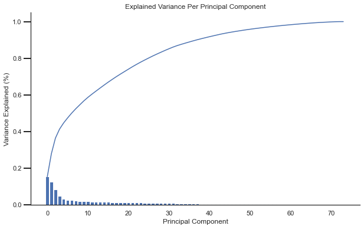

```python
# Apply PCA to the data.
X=azdias_std
X_pca = PCA(random_state=1234).fit(X)
scree_plot(X_pca)
```

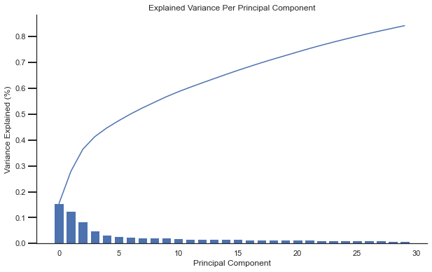

```python
# Re-apply PCA to the data while selecting for number of components to retain.
X30_pca=PCA(n_components=30, random_state=1234).fit(X)
scree_plot(X30_pca)
```

```python
n=30
print('The cumulative explain variance with {} values is {}'.format(n,np.cumsum(X30_pca.explained_variance_ratio_[:n])[-1]))
```

```
The cumulative explain variance with 30 values is 0.8425442104293182
```

### Discussion 2.2: Perform Dimensionality Reduction

> - It is possible that too many features in the dataset lead to overfitting or the [curse of dimensionality.](https://en.wikipedia.org/wiki/Curse_of_dimensionality) **Principal Component Analysis (PCA)** is a feature extraction technique* that is used to reduce the dimensionality of your dataset. The reduced features are called **principal components**, or **latent features**. These principal components are simply a linear combination of the original features in the dataset and they have two major properties:
>   - They aim to capture the most amount of variability in the original dataset.
>   - They are orthogonal to (independent of) one another.
> - The amount of variance explained by each component is called an **eigenvalue**. By visualizing the combined plot of explained variance and cumulative **explained variance**, it's observed that the most related **30 principal components** provide most of the information as the cumulative variance explained curve estabilizes by that point. Principal components are also known as **eigenvectors.**

> *Feature Selection and Feature Extraction are two general approaches for reducing the number of features in your data. Feature Selection processes result in a subset of the most significant original features in the data, while Feature Extraction methods like PCA construct new latent features that well represent the original data.

### Step 2.3: Interpret Principal Components

Once we've got transformed principal components, it's a nice idea to check out the weight of each variable on the first few components to see if they can be interpreted in some fashion.

Each **principal component** is a unit vector that points in the direction of highest variance (after accounting for the variance captured by earlier principal components). The further a weight is from zero, the more the principal component is in the direction of the corresponding feature. If two features have large weights of the same sign (both positive or both negative), then increases in one tend expect to be associated with increases in the other. To contrast, features with different signs can be expected to show a negative correlation: increases in one variable should result in a decrease in the other.

- To investigate the features, each weight will be map to their corresponding feature name, then sort the features according to weight. The most interesting features for each principal component will be those at the beginning and end of the sorted list. Use the data dictionary document to help you understand these most prominent features, their relationships, and what a positive or negative value on the principal component might indicate.
- Investigate and interpret feature associations from the first three principal components in this substep.

```python
def plot_weights(pca, n):
    '''Visualizing 10 top feature weights for the *i*-th principal component'''
    pca_weights = pd.DataFrame(pca.components_, columns = df_azdias_std.keys())

    weights=pca_weights.iloc[n,:].sort_values(ascending=False, key=abs)[:10]
    map_series=weights>0

    weights.plot(kind='barh',color=map_series.map({True: 'g', False: 'r'}))

    plt.show()
```

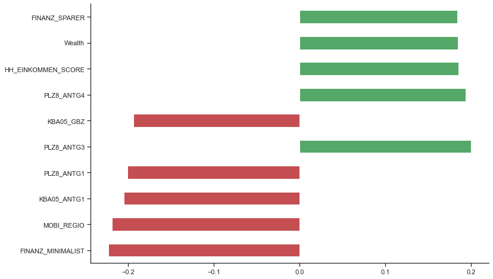

```python
# Map weights for the third principal component to corresponding feature names
# and then print the linked values, sorted by weight.
plot_weights(X30_pca, 0)
```

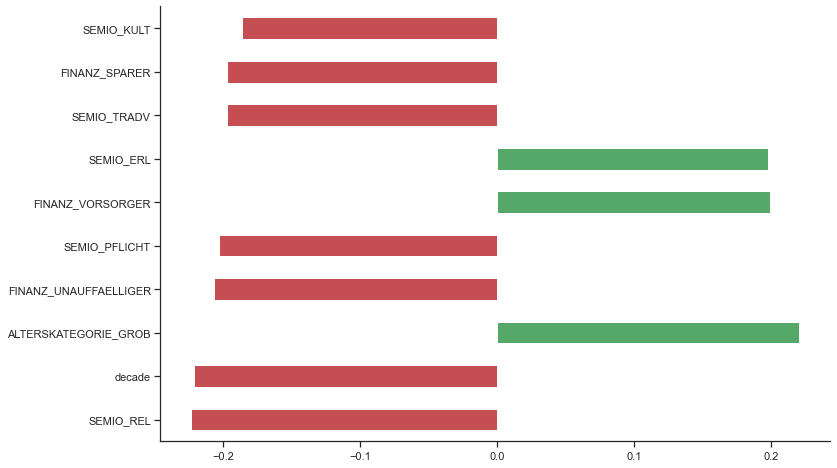

```python
# Map weights for the first principal component to corresponding feature names
# and then print the linked values, sorted by weight.
plot_weights(X30_pca, 1)
```

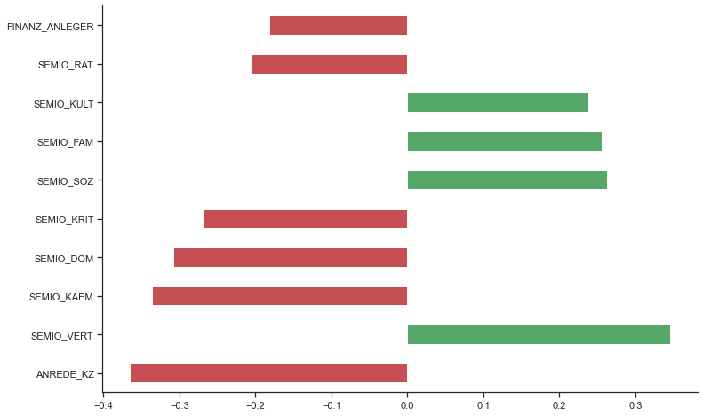

```python
# Map weights for the second principal component to corresponding feature names
# and then print the linked values, sorted by weight.
plot_weights(X30_pca, 2)
```

### Discussion 2.3: Interpret Principal Components

> - First principal component extracts most info from features related with buying power, like FINANZ_MINIMALIST, HH_EINKOMMENN_SCORE, engineered feature WEALTH, FINANZ_SPARER, and area of living (houses density, etc..)
> - Second principal component extracts most info from features related with SEMIO *levels (related with personality typology), FINANZ* levels (financial typology), engineered feature DECADE (of youth's movement) and ALTERSKATEGORIE_GROB (estimated age)
> - Third principal component extracts most info from features related with gender and SEMIO_ levels (related with personality typology),

## Step 3: Clustering

### Step 3.1: Apply Clustering to General Population

After cleaning, assesing, scaled and transformed the demographics data, it's time to see how the data clusters in the principal components space. In this substep, we will apply k-means clustering to the dataset and use the average within-cluster distances from each point to their assigned cluster's centroid to decide on a number of clusters to keep.

- Sklearn's KMeans class to perform k-means clustering on the PCA-transformed data.
- Computing the average difference from each point to its assigned cluster's center.
- Checking how the average distance decreases with an increasing number of clusters. However, each additional cluster provides a smaller net benefit. This fact is used to select a final number of clusters in which to group the data. **Warning: This step requires high amount of time.
- Once a final number of clusters is selected, re-fit a KMeans instance to perform the clustering operation. Make sure that you also obtain the cluster assignments for the general demographics data, since you'll be using them in the final Step 3.3.

Go back to Index

```python
azdias_30pca=X30_pca.transform(X)
```

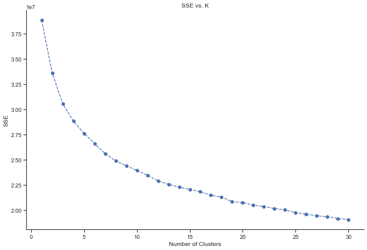

```python
# Investigate the change in within-cluster distance across number of clusters.
# HINT: Use matplotlib's plot function to visualize this relationship.

def get_kmeans_score(data, center):
    '''
    returns the kmeans score regarding SSE for points to centers
    INPUT:
        data - the dataset you want to fit kmeans to
        center - the number of centers you want (the k value)
    OUTPUT:
        score - the SSE score for the kmeans model fit to the data
    '''
    #instantiate kmeans
    kmeans = KMeans(n_clusters=center)

    # Then fit the model to your data using the fit method
    model = kmeans.fit(data)

    # Obtain a score related to the model fit
    score = np.abs(model.score(data))

    return score

scores = []
centers = list(range(1,31))

for center in centers:
    scores.append(get_kmeans_score(azdias_30pca, center))

plt.plot(centers, scores, linestyle='--', marker='o', color='b');
plt.xlabel('Number of Clusters');
plt.ylabel('SSE');
plt.title('SSE vs. K');
```

> - Chosen number of clusters to segment the population based on above plot: **10 clusters**

```python
# Re-fit the k-means model with the selected number of clusters and obtain
# cluster predictions for the general population demographics data.

n_clusters=10
k10means = KMeans(n_clusters=n_clusters,random_state=1234,n_jobs=-1)
dem_clusters = k10means.fit_predict(azdias_30pca)
```

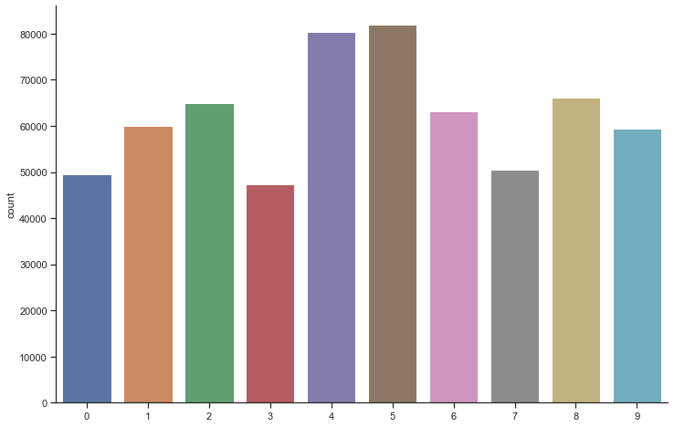

```python
sns.countplot(pd.Series(dem_clusters))
plt.show()
```

### Step 3.2: Apply All Steps to the Customer Data

Now that clusters and cluster centers have been defined for the general population, it's time to see how the customer data maps on to those clusters. Take care to not confuse this for re-fitting all of the models to the customer data. Instead, you're going to use the fits from the general population to clean, transform, and cluster the customer data. In the last step of the project, you will interpret how the general population fits apply to the customer data.

Go back to Index

```python
# Load in the customer demographics data.
customers = pd.read_csv('Udacity_CUSTOMERS_Subset.csv', sep=';')
display(customers.head())
display(customers.describe())
```

|  | AGER_TYP | ALTERSKATEGORIE_GROB | ANREDE_KZ | CJT_GESAMTTYP | FINANZ_MINIMALIST | FINANZ_SPARER | FINANZ_VORSORGER | FINANZ_ANLEGER | FINANZ_UNAUFFAELLIGER | FINANZ_HAUSBAUER | FINANZTYP | GEBURTSJAHR | GFK_URLAUBERTYP | GREEN_AVANTGARDE | HEALTH_TYP | LP_LEBENSPHASE_FEIN | LP_LEBENSPHASE_GROB | LP_FAMILIE_FEIN | LP_FAMILIE_GROB | LP_STATUS_FEIN | LP_STATUS_GROB | NATIONALITAET_KZ | PRAEGENDE_JUGENDJAHRE | RETOURTYP_BK_S | SEMIO_SOZ | SEMIO_FAM | SEMIO_REL | SEMIO_MAT | SEMIO_VERT | … |
| --- | --- | --- | --- | --- | --- | --- | --- | --- | --- | --- | --- | --- | --- | --- | --- | --- | --- | --- | --- | --- | --- | --- | --- | --- | --- | --- | --- | --- | --- | --- |
| 0 | 2 | 4 | 1 | 5.0 | 5 | 1 | 5 | 1 | 2 | 2 | 2 | 0 | 4.0 | 1 | 1 | 20.0 | 5.0 | 2.0 | 2.0 | 10.0 | 5.0 | 1 | 4 | 5.0 | 6 | 5 | 2 | 6 | 6 | … |
| 1 | -1 | 4 | 1 | NaN | 5 | 1 | 5 | 1 | 3 | 2 | 2 | 0 | NaN | 0 | 1 | NaN | NaN | NaN | NaN | NaN | NaN | 1 | 0 | NaN | 3 | 6 | 2 | 6 | 7 | … |
| 2 | -1 | 4 | 2 | 2.0 | 5 | 1 | 5 | 1 | 4 | 4 | 2 | 0 | 3.0 | 1 | 2 | 13.0 | 3.0 | 1.0 | 1.0 | 10.0 | 5.0 | 1 | 4 | 5.0 | 2 | 2 | 1 | 3 | 3 | … |
| 3 | 1 | 4 | 1 | 2.0 | 5 | 1 | 5 | 2 | 1 | 2 | 6 | 0 | 10.0 | 0 | 2 | 0.0 | 0.0 | 0.0 | 0.0 | 9.0 | 4.0 | 1 | 1 | 3.0 | 6 | 5 | 3 | 4 | 7 | … |
| 4 | -1 | 3 | 1 | 6.0 | 3 | 1 | 4 | 4 | 5 | 2 | 2 | 1960 | 2.0 | 0 | 3 | 31.0 | 10.0 | 10.0 | 5.0 | 1.0 | 1.0 | 1 | 8 | 5.0 | 4 | 5 | 4 | 6 | 5 | … |

|  | AGER_TYP | ALTERSKATEGORIE_GROB | ANREDE_KZ | CJT_GESAMTTYP | FINANZ_MINIMALIST | FINANZ_SPARER | FINANZ_VORSORGER | FINANZ_ANLEGER | FINANZ_UNAUFFAELLIGER | FINANZ_HAUSBAUER | FINANZTYP | GEBURTSJAHR | GFK_URLAUBERTYP | GREEN_AVANTGARDE | HEALTH_TYP | LP_LEBENSPHASE_FEIN | LP_LEBENSPHASE_GROB | LP_FAMILIE_FEIN | LP_FAMILIE_GROB | LP_STATUS_FEIN | LP_STATUS_GROB | NATIONALITAET_KZ | PRAEGENDE_JUGENDJAHRE | RETOURTYP_BK_S | SEMIO_SOZ | SEMIO_FAM | SEMIO_REL | SEMIO_MAT | SEMIO_VERT | … |
| --- | --- | --- | --- | --- | --- | --- | --- | --- | --- | --- | --- | --- | --- | --- | --- | --- | --- | --- | --- | --- | --- | --- | --- | --- | --- | --- | --- | --- | --- | --- |
| count | 191652.000000 | 191652.000000 | 191652.000000 | 188439.000000 | 191652.000000 | 191652.000000 | 191652.000000 | 191652.000000 | 191652.000000 | 191652.000000 | 191652.000000 | 191652.000000 | 188439.000000 | 191652.000000 | 191652.000000 | 188439.000000 | 188439.000000 | 188439.000000 | 188439.000000 | 188439.000000 | 188439.000000 | 191652.000000 | 191652.000000 | 188439.000000 | 191652.000000 | 191652.000000 | 191652.000000 | 191652.000000 | 191652.000000 | … |
| mean | 0.344359 | 3.060907 | 1.376432 | 3.677928 | 3.963773 | 2.057051 | 4.183317 | 2.439808 | 2.646176 | 2.781176 | 4.137958 | 1003.392733 | 6.302268 | 0.367171 | 1.198396 | 18.181571 | 5.422694 | 4.254448 | 2.355043 | 6.687910 | 3.209251 | 0.773433 | 4.248273 | 3.716311 | 3.742137 | 4.414026 | 4.112788 | 3.883163 | 4.185279 | … |
| std | 1.391672 | 1.086254 | 0.484492 | 1.813975 | 1.036230 | 1.319422 | 0.995365 | 1.697932 | 1.586506 | 1.147353 | 1.503946 | 974.531081 | 2.877181 | 0.482035 | 1.450937 | 15.009985 | 4.717907 | 4.492807 | 2.052142 | 3.090573 | 1.436958 | 0.495983 | 3.807671 | 1.113933 | 1.718039 | 1.733128 | 2.070958 | 1.840131 | 2.367407 | … |
| min | -1.000000 | 1.000000 | 1.000000 | 1.000000 | 1.000000 | 1.000000 | 1.000000 | 1.000000 | 1.000000 | 1.000000 | 1.000000 | 0.000000 | 1.000000 | 0.000000 | -1.000000 | 0.000000 | 0.000000 | 0.000000 | 0.000000 | 1.000000 | 1.000000 | 0.000000 | 0.000000 | 1.000000 | 1.000000 | 1.000000 | 1.000000 | 1.000000 | 1.000000 | … |
| 25% | -1.000000 | 3.000000 | 1.000000 | 2.000000 | 3.000000 | 1.000000 | 3.000000 | 1.000000 | 1.000000 | 2.000000 | 2.000000 | 0.000000 | 5.000000 | 0.000000 | -1.000000 | 0.000000 | 0.000000 | 0.000000 | 0.000000 | 5.000000 | 2.000000 | 0.000000 | 0.000000 | 3.000000 | 2.000000 | 3.000000 | 2.000000 | 2.000000 | 1.000000 | … |
| 50% | 0.000000 | 3.000000 | 1.000000 | 4.000000 | 4.000000 | 1.000000 | 5.000000 | 2.000000 | 2.000000 | 3.000000 | 4.000000 | 1926.000000 | 5.000000 | 0.000000 | 2.000000 | 16.000000 | 4.000000 | 2.000000 | 2.000000 | 7.000000 | 3.000000 | 1.000000 | 4.000000 | 3.000000 | 3.000000 | 5.000000 | 4.000000 | 4.000000 | 5.000000 | … |
| 75% | 2.000000 | 4.000000 | 2.000000 | 6.000000 | 5.000000 | 4.000000 | 5.000000 | 5.000000 | 5.000000 | 3.000000 | 5.000000 | 1949.000000 | 9.000000 | 1.000000 | 2.000000 | 36.000000 | 12.000000 | 10.000000 | 5.000000 | 10.000000 | 5.000000 | 1.000000 | 6.000000 | 5.000000 | 6.000000 | 6.000000 | 7.000000 | 5.000000 | 6.000000 | … |
| max | 3.000000 | 9.000000 | 2.000000 | 6.000000 | 5.000000 | 5.000000 | 5.000000 | 5.000000 | 5.000000 | 5.000000 | 6.000000 | 2017.000000 | 12.000000 | 1.000000 | 3.000000 | 40.000000 | 12.000000 | 11.000000 | 5.000000 | 10.000000 | 5.000000 | 3.000000 | 15.000000 | 5.000000 | 7.000000 | 7.000000 | 7.000000 | 7.000000 | 7.000000 | … |

```python
# Main cleaning function

def new_clean_data(df):
    """
    Perform feature trimming, re-encoding, and engineering for demographics
    data. Difference with basic function clean_data is that the above drop rows with >15% nans and this one removes completely these rows

    INPUT: Demographics DataFrame
    OUTPUT: Trimmed and cleaned demographics DataFrame
    """
    mapper=pd.read_csv('AZDIAS_Feature_Summary.csv', delimiter=';')
    mapper_column_name='attribute'
    mapper_column_definition= 'missing_or_unknown'
    non_numerical_indicators=['X', 'XX']

    # Remove brackets and split strings into lists in feat_info.missing_or_unknown
    mapper[mapper_column_definition] = mapper[mapper_column_definition].str.strip('[').str.strip(']').str.split(',')
    # convert missing value codes into NaNs, ...
    df=mapping_nan(df, mapper, mapper_column_name, mapper_column_definition, non_numerical_indicators)
    print('Missing values codes converted into NaNs',df.shape)
    # remove selected columns and rows, ...
    df,mapper=drop_cols(df,mapper)
    print('Identified and removed cols',df.shape)
    df=drop_missing_rows(df)
    print('Identified and removed rows',df.shape)
    # select, re-encode, and engineer column values.
    df= encode_cat(df, mapper)
    print('Identified and encoded categorical variables',df.shape)
    df= engineer_mix(df, mapper)
    print('Identified and treated mixed variables',df.shape)

    # Return the cleaned dataframe.
    return df
```

```python
# Preprocessing: mapping_nan, drop_cols >32% NaNs, drop_rows with any NaNs, encode_cat, engineer_mix (if they haven't been removed)
customers_cleaned=new_clean_data(customers)
```

```
Missing values codes converted into NaNs (191652, 85)
Identified and removed cols (191652, 79)
Identified and removed rows (115643, 79)
Identified and encoded categorical variables (115643, 76)
Identified and treated mixed variables (115643, 74)
```

```python
# Feature Transformation: standarized values between -1 and 1 and dimensionality reduction (30 principal components)
customers_std=scaler.transform(customers_cleaned)
print('Standarized values between -1 and 1', customers_std.shape)
customers_pca=X30_pca.transform(customers_std)
print('Standarized values between -1 and 1', customers_pca.shape)
```

```
Standarized values between -1 and 1 (115643, 74)
Standarized values between -1 and 1 (115643, 30)
```

```python
# Clustering
#kmeans = KMeans(n_clusters=n_clusters, random_state=1234, max_iter=30, n_jobs=-1).fit(customers_std)
customer_clusters = k10means.predict(customers_pca)
```

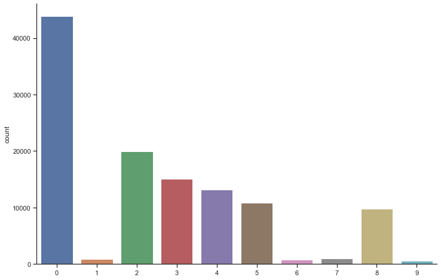

```python
# Apply preprocessing, feature transformation, and clustering from the general
# demographics onto the customer data, obtaining cluster predictions for the
# customer demographics data.
sns.countplot(pd.Series(customer_clusters))
plt.show()
```

### Step 3.3: Compare Customer Data to Demographics Data

At this point, you have clustered data based on demographics of the general population of Germany, and seen how the customer data for a mail-order sales company maps onto those demographic clusters. In this final substep, you will compare the two cluster distributions to see where the strongest customer base for the company is.

Consider the proportion of persons in each cluster for the general population, and the proportions for the customers. If we think the company's customer base to be universal, then the cluster assignment proportions should be fairly similar between the two. If there are only particular segments of the population that are interested in the company's products, then we should see a mismatch from one to the other. If there is a higher proportion of persons in a cluster for the customer data compared to the general population (e.g. 5% of persons are assigned to a cluster for the general population, but 15% of the customer data is closest to that cluster's centroid) then that suggests the people in that cluster to be a target audience for the company. On the other hand, the proportion of the data in a cluster being larger in the general population than the customer data (e.g. only 2% of customers closest to a population centroid that captures 6% of the data) suggests that group of persons to be outside of the target demographics.

Which cluster or clusters are underrepresented in the customer dataset compared to the general population, and what kinds of people are typified by these clusters?

Go back to Index

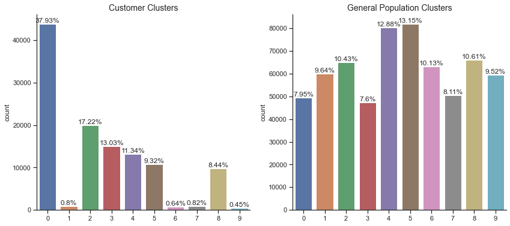

```python
# Compare the proportion of data in each cluster for the customer data to the
# proportion of data in each cluster for the general population.
figure, axs = plt.subplots(nrows=1, ncols=2, figsize = (14,6))

sns.countplot(pd.Series(customer_clusters),ax=axs[0])
axs[0].set_title('Customer Clusters', fontsize=14)
for i in range(n_clusters):
        axs[0].annotate(r"%s%%" % np.round(pd.Series(customer_clusters).value_counts(normalize=True, sort=False).iloc[i]*100,2),(i,pd.Series(customer_clusters).value_counts(sort=False).iloc[i]+0.2), va="bottom", ha="center", fontsize=12)
sns.countplot(pd.Series(dem_clusters),ax=axs[1])
axs[1].set_title('General Population Clusters', fontsize=14)
for i in range(n_clusters):
        axs[1].annotate(r"%s%%" % np.round(pd.Series(dem_clusters).value_counts(normalize=True, sort=False).iloc[i]*100,2),(i,pd.Series(dem_clusters).value_counts(sort=False).iloc[i]+0.2), va="bottom", ha="center", fontsize=12)
plt.show()
```

> - **Cluster 0** is overrepresented in customer base compared with general population distribution.
> - **Clusters 1, 6, 7 and 9** are underrepresented in customer data comparing with general demographics

```python
# What kinds of people are part of a cluster that is overrepresented in the
# customer data compared to the general population?
centroid_0 = scaler.inverse_transform(X30_pca.inverse_transform(k10means.cluster_centers_[0]))
centroid0_df=pd.DataFrame(centroid_0, index=customers_cleaned.columns, columns={'centroid_0'})
centroid0_df
```

|  | centroid_0 |
| --- | --- |
| ALTERSKATEGORIE_GROB | 3.319795 |
| ANREDE_KZ | 1.062107 |
| FINANZ_MINIMALIST | 4.778395 |
| FINANZ_SPARER | 1.425609 |
| FINANZ_VORSORGER | 4.521977 |
| FINANZ_ANLEGER | 1.297317 |
| FINANZ_UNAUFFAELLIGER | 1.929824 |
| FINANZ_HAUSBAUER | 2.185629 |
| GREEN_AVANTGARDE | 0.930862 |
| HEALTH_TYP | 1.995632 |
| RETOURTYP_BK_S | 4.091406 |
| SEMIO_SOZ | 5.242145 |
| SEMIO_FAM | 4.804032 |
| SEMIO_REL | 3.753554 |
| SEMIO_MAT | 3.855531 |
| SEMIO_VERT | 6.201340 |
| SEMIO_LUST | 5.437845 |
| SEMIO_ERL | 4.087345 |
| SEMIO_KULT | 4.880310 |
| SEMIO_RAT | 2.703587 |
| SEMIO_KRIT | 3.182164 |
| SEMIO_DOM | 3.310579 |
| SEMIO_KAEM | 2.564408 |
| SEMIO_PFLICHT | 3.201542 |
| SEMIO_TRADV | 3.146800 |
| SOHO_KZ | 0.008401 |
| VERS_TYP | 1.494436 |
| ANZ_PERSONEN | 2.305003 |
| ANZ_TITEL | 0.014177 |
| HH_EINKOMMEN_SCORE | 2.525126 |
| W_KEIT_KIND_HH | 4.419253 |
| WOHNDAUER_2008 | 8.492347 |
| ANZ_HAUSHALTE_AKTIV | 1.671225 |
| ANZ_HH_TITEL | 0.022819 |
| KONSUMNAEHE | 3.326996 |
| MIN_GEBAEUDEJAHR | 1992.609428 |
| OST_WEST_KZ | 0.071167 |
| KBA05_ANTG1 | 2.686960 |
| KBA05_ANTG2 | 1.165137 |
| KBA05_ANTG3 | 0.087366 |
| KBA05_ANTG4 | 0.010829 |
| KBA05_GBZ | 4.077964 |
| BALLRAUM | 3.964690 |
| EWDICHTE | 4.055329 |
| INNENSTADT | 4.528092 |
| GEBAEUDETYP_RASTER | 3.925693 |
| KKK | 2.046254 |
| MOBI_REGIO | 4.100686 |
| ONLINE_AFFINITAET | 3.078696 |
| REGIOTYP | 3.366774 |
| KBA13_ANZAHL_PKW | 692.847934 |
| PLZ8_ANTG1 | 2.748087 |
| PLZ8_ANTG2 | 2.626317 |
| PLZ8_ANTG3 | 1.214611 |
| PLZ8_ANTG4 | 0.397002 |
| PLZ8_HHZ | 3.722957 |
| PLZ8_GBZ | 3.903939 |
| ARBEIT | 3.025174 |
| ORTSGR_KLS9 | 5.396464 |
| RELAT_AB | 3.006951 |
| CJT_GESAMTTYP_2.0 | 0.206502 |
| CJT_GESAMTTYP_3.0 | 0.256509 |
| CJT_GESAMTTYP_4.0 | 0.185275 |
| CJT_GESAMTTYP_5.0 | 0.115143 |
| CJT_GESAMTTYP_6.0 | 0.076467 |
| FINANZTYP_2 | 0.164906 |
| FINANZTYP_3 | 0.039409 |
| FINANZTYP_4 | 0.034194 |
| FINANZTYP_5 | 0.447695 |
| FINANZTYP_6 | 0.386487 |
| decade | 63.308883 |
| movement | 0.069138 |
| Wealth | 2.115689 |
| Life_stage | 3.602706 |

```python
# What kinds of people are part of a cluster that is underrepresented in the
# customer data compared to the general population?
centroid_1 = scaler.inverse_transform(X30_pca.inverse_transform(k10means.cluster_centers_[1]))
centroid_6 = scaler.inverse_transform(X30_pca.inverse_transform(k10means.cluster_centers_[6]))
centroid_7 = scaler.inverse_transform(X30_pca.inverse_transform(k10means.cluster_centers_[7]))
centroid_9 = scaler.inverse_transform(X30_pca.inverse_transform(k10means.cluster_centers_[9]))

under_centroid_df=pd.DataFrame({'centroid_1':centroid_1, 'centroid_6': centroid_6,'centroid_7': centroid_7,'centroid_9':centroid_9}, index=customers_cleaned.columns)
under_centroid_df
```

|  | centroid_1 | centroid_6 | centroid_7 | centroid_9 |
| --- | --- | --- | --- | --- |
| ALTERSKATEGORIE_GROB | 1.713415 | 1.506934 | 1.979847 | 1.841006 |
| ANREDE_KZ | 1.996324 | 2.030423 | 0.970450 | 0.964855 |
| FINANZ_MINIMALIST | 2.353513 | 1.119843 | 3.248221 | 1.910810 |
| FINANZ_SPARER | 3.934046 | 4.228111 | 4.077263 | 4.335073 |
| FINANZ_VORSORGER | 2.170339 | 2.237013 | 1.926419 | 2.097180 |
| FINANZ_ANLEGER | 4.346148 | 4.116632 | 3.757511 | 3.527415 |
| FINANZ_UNAUFFAELLIGER | 3.894077 | 3.625227 | 4.140610 | 3.699215 |
| FINANZ_HAUSBAUER | 2.855426 | 4.281453 | 2.000606 | 3.584222 |
| GREEN_AVANTGARDE | 0.215347 | 0.045902 | 0.347388 | 0.127940 |
| HEALTH_TYP | 2.226312 | 2.196526 | 2.292980 | 2.348290 |
| RETOURTYP_BK_S | 2.339952 | 2.570715 | 2.362471 | 2.785895 |
| SEMIO_SOZ | 2.895318 | 3.347874 | 6.121942 | 6.541309 |
| SEMIO_FAM | 3.542415 | 3.885419 | 6.300672 | 6.675836 |
| SEMIO_REL | 5.074893 | 5.359597 | 5.955226 | 6.151363 |
| SEMIO_MAT | 4.984315 | 5.109638 | 4.987937 | 4.986325 |
| SEMIO_VERT | 2.475202 | 2.192364 | 6.245007 | 6.021718 |
| SEMIO_LUST | 3.019580 | 2.480571 | 3.451194 | 2.863704 |
| SEMIO_ERL | 4.280003 | 4.048841 | 2.439186 | 2.188041 |
| SEMIO_KULT | 4.040414 | 4.206366 | 6.657415 | 6.824010 |
| SEMIO_RAT | 6.265724 | 6.444971 | 4.037174 | 4.035414 |
| SEMIO_KRIT | 5.472814 | 5.524430 | 2.730187 | 2.709761 |
| SEMIO_DOM | 6.171642 | 6.311153 | 2.798191 | 2.792532 |
| SEMIO_KAEM | 5.677248 | 6.252983 | 2.033809 | 2.399248 |
| SEMIO_PFLICHT | 6.089508 | 6.406345 | 5.453953 | 5.641507 |
| SEMIO_TRADV | 5.860505 | 5.964621 | 4.856302 | 4.797561 |
| SOHO_KZ | 0.008739 | 0.007965 | 0.010285 | 0.008476 |
| VERS_TYP | 1.399182 | 1.427370 | 1.533353 | 1.539303 |
| ANZ_PERSONEN | 2.074023 | 1.580429 | 2.162002 | 1.495970 |
| ANZ_TITEL | 0.002431 | 0.001537 | 0.002080 | 0.001584 |
| HH_EINKOMMEN_SCORE | 4.145795 | 5.658946 | 3.806183 | 5.537530 |
| W_KEIT_KIND_HH | 3.179291 | 3.910525 | 3.494939 | 4.404703 |
| WOHNDAUER_2008 | 7.658209 | 7.192539 | 7.782945 | 7.105928 |
| ANZ_HAUSHALTE_AKTIV | 3.028542 | 14.642830 | 3.137109 | 15.676645 |
| ANZ_HH_TITEL | 0.007968 | 0.053007 | 0.010188 | 0.058705 |
| KONSUMNAEHE | 3.693499 | 2.107456 | 3.646905 | 2.081574 |
| MIN_GEBAEUDEJAHR | 1992.751361 | 1992.356464 | 1992.674215 | 1992.361681 |
| OST_WEST_KZ | 0.146807 | 0.279577 | 0.159107 | 0.313331 |
| KBA05_ANTG1 | 2.298512 | 0.423674 | 2.363134 | 0.372110 |
| KBA05_ANTG2 | 1.361947 | 1.287425 | 1.353684 | 1.292115 |
| KBA05_ANTG3 | 0.211746 | 1.157471 | 0.225453 | 1.149150 |
| KBA05_ANTG4 | 0.045791 | 0.605608 | 0.036028 | 0.642016 |
| KBA05_GBZ | 3.938459 | 2.191376 | 3.920126 | 2.136936 |
| BALLRAUM | 4.946775 | 3.182072 | 4.884692 | 3.151870 |
| EWDICHTE | 3.011071 | 5.174491 | 3.053388 | 5.082708 |
| INNENSTADT | 5.481140 | 3.358375 | 5.426070 | 3.337566 |
| GEBAEUDETYP_RASTER | 3.986458 | 3.395643 | 3.999200 | 3.359222 |
| KKK | 2.632502 | 2.891542 | 2.675930 | 2.901248 |
| MOBI_REGIO | 3.853247 | 1.800091 | 3.875010 | 1.730007 |
| ONLINE_AFFINITAET | 3.698494 | 3.021007 | 3.876753 | 2.934290 |
| REGIOTYP | 4.191482 | 4.982040 | 4.194288 | 4.894005 |
| KBA13_ANZAHL_PKW | 696.557289 | 518.133457 | 693.518824 | 518.129914 |
| PLZ8_ANTG1 | 2.867108 | 1.461560 | 2.853731 | 1.457960 |
| PLZ8_ANTG2 | 2.403979 | 3.324672 | 2.412985 | 3.300225 |
| PLZ8_ANTG3 | 0.965432 | 2.418191 | 1.001395 | 2.404583 |
| PLZ8_ANTG4 | 0.249082 | 1.279573 | 0.280646 | 1.281082 |
| PLZ8_HHZ | 3.525972 | 3.749454 | 3.549820 | 3.749526 |
| PLZ8_GBZ | 3.924022 | 2.697652 | 3.897854 | 2.687323 |
| ARBEIT | 2.763801 | 3.674749 | 2.793601 | 3.680869 |
| ORTSGR_KLS9 | 3.996485 | 6.969518 | 4.119910 | 6.881292 |
| RELAT_AB | 2.497480 | 3.716239 | 2.531565 | 3.713957 |
| CJT_GESAMTTYP_2.0 | 0.056780 | 0.094789 | 0.029125 | -0.005922 |
| CJT_GESAMTTYP_3.0 | 0.254349 | 0.236120 | 0.103537 | 0.335983 |
| CJT_GESAMTTYP_4.0 | 0.274685 | 0.249650 | 0.431880 | 0.432440 |
| CJT_GESAMTTYP_5.0 | 0.077524 | 0.157513 | 0.276658 | 0.112083 |
| CJT_GESAMTTYP_6.0 | 0.287362 | 0.225368 | 0.123727 | 0.084408 |
| FINANZTYP_2 | 0.017906 | 0.010750 | 0.028613 | 0.005102 |
| FINANZTYP_3 | 0.089506 | 0.012799 | 0.245301 | 0.013675 |
| FINANZTYP_4 | 0.214632 | 0.081073 | 0.245417 | 0.191124 |
| FINANZTYP_5 | 0.021895 | 0.017738 | 0.025403 | 0.026978 |
| FINANZTYP_6 | 0.166000 | 0.176306 | 0.129951 | 0.234887 |
| decade | 86.788708 | 86.089629 | 88.244908 | 86.889146 |
| movement | 0.784653 | 0.954098 | 0.652612 | 0.872060 |
| Wealth | 2.547319 | 4.355807 | 2.485453 | 4.406913 |
| Life_stage | 3.267741 | 2.095003 | 3.315438 | 1.994520 |